# Sample Analysis

Cillian McHugh

1st November 2021

# Sample Analysis

Below is a sample analysis for cognitive load Study 6.

```r
rm(list = ls())
library(citr)
#install.packages("sjstats")
library(plyr)
library(foreign)
library(car)
```

```r
library(desnum)
library(ggplot2)
library(extrafont)
#devtools::install_github("crsh/papaja")
library(papaja)
#library("dplyr")
library("afex")
library("tibble")
library(scales)
#install.packages("metap")
library(metap)
library(pwr)
library(lsr)
#install.packages("sjstats")
library(sjstats)
library(DescTools)
#inatall.packages("ggstatsplot")
#library(ggstatsplot)
library(VGAM)
library(nnet)
library(mlogit)
library(reshape2)
#install.packages("powerMediation")
library("powerMediation")


#source("load_all_data.R")

#devtools::install_github("benmarwick/wordcountaddin")
#library(wordcountaddin)
#wordcountaddin::text_stats("cogload_1to5_25Sept19.Rmd")
getwd()
```

```
## [1] "/home/cillian/Dropbox/College/research/Research_general/cog_load/moral_dumbfounding_and_cognitive_load"
```

```r
pwr.chisq.test(w=.35,df=(3-1),sig.level = .05, power=.8)
```

```
##
##      Chi squared power calculation
##
##               w = 0.35
##               N = 78.65052
##              df = 2
##       sig.level = 0.05
##           power = 0.8
##
## NOTE: N is the number of observations
```

```r
pwr.chisq.test(w=.21,df=(3-1),sig.level = .05, power=.8)
```

```
##
##      Chi squared power calculation
##
##               w = 0.21
##               N = 218.4737
##              df = 2
##       sig.level = 0.05
##           power = 0.8
##
## NOTE: N is the number of observations
```

```r
pwr.chisq.test(w=.07,df=(3-1),sig.level = .05, power=.8)
```

```
##
##      Chi squared power calculation
##
##               w = 0.07
##               N = 1966.263
##              df = 2
##       sig.level = 0.05
##           power = 0.8
##
## NOTE: N is the number of observations
```

```r
# https://www.real-statistics.com/chi-square-and-f-distributions/effect-size-chi-square/
```

```r
powerMediation::SSizeLogisticCon(.5,exp(.405))
```

```
## [1] 192
```

```r
powerMediation::SSizeLogisticCon(.2,(1.49), .05, .8)
```

```
## [1] 309
```

```r
powerMediation::SSizeLogisticCon(.2,(3.45), .05, .8)
```

```
## [1] 32
```

```r
powerMediation::SSizeLogisticCon(.2,(9), .05, .8)
```

```
## [1] 11
```

```r
# https://rdrr.io/cran/powerMediation/man/powerLogisticCon.html
# http://core.ecu.edu/psyc/wuenschk/docs30/EffectSizeConventions.pdf small 1.49, med 3.45, large 9
```

Moral dumbfounding occurs when people defend a moral judgement even though they cannot provide a reason in support of this judgement (Haidt, 2001; Haidt, Björklund, & Murphy, 2000; see also McHugh, McGann, Igou, & Kinsella, 2017, 2020). It is seen as evidence for the intuitive nature of moral judgements and has been cited as support for both intuitionist and dual-process theories of moral judgement (e.g., Cameron, Payne, & Doris, 2013; Crockett, 2013; Cushman, 2013; Cushman, Young, & Greene, 2010; Greene, 2008; Haidt, 2001; Prinz, 2005). Despite the influence of moral dumbfounding on the morality literature, the phenomenon is not well understood. Until recently (McHugh, McGann, Igou, & Kinsella, 2017, 2020; e.g., Royzman, Kim, & Leeman, 2015), empirical evidence testing the phenomenon was limited to a single study with a final sample of *N* = 30, unpublished in peer-reviewed form. The dumbfounding paradigm involves presenting participants with a moral scenario, and asking them to judge the behaviour in the scenario. Participants are then asked to provide reasons for their judgement. Typically the scenarios in the dumbfounding paradigm depict “harmless taboos” (Haidt & Björklund, 2008, p. 196). McHugh, McGann, Igou, & Kinsella (2017), building on the original work by Haidt, Björklund, & Murphy (2000), identified two measurable responses that may be taken as indicators of moral dumbfounding. Firstly, people may explicitly admit to not having reasons for their judgement. Secondly, people may use unsupported declarations (“it’s just wrong”) or tautological reasons (“because it’s incest”) as justifications for a judgement. The current research uses the methods developed by McHugh, McGann, Igou, & Kinsella (2017) to test one potential explanation of moral dumbfounding.

# Moral Dumbfounding: A Dual-Process Perspective

Drawing on dual-process theories of moral judgement (Bago & De Neys, 2019; Brand, 2016; Cushman, 2013; e.g., Greene, 2008), the studies presented here aim to test the hypothesis that moral dumbfounding can be explained as a result of a dual-process conflict (Bonner & Newell, 2010; De Neys, 2012; De Neys & Glumicic, 2008; Evans, 2007; see also De Neys & Pennycook, 2019). Conflicts occur when a habitual/intuitive response is different from a response that results from deliberation. Examples of such conflicts include, base rate neglect problems (Bonner & Newell, 2010; De Neys, 2012; De Neys & Glumicic, 2008; Evans, 2007), the conjunction fallacy (De Neys, 2012; Tversky & Kahneman, 1983), and the persistence of apparently “irrational” behaviours (Evans, 2007), and compulsive behaviours (e.g. overeating, smoking, or gambling, Evans, 2008).

Another example of this kind of dual-process conflict is identified by Lerner & Goldberg (1999), discussing a study by Rozin, Markwith, & McCauley (1994). In this study, Rozin, Markwith, & McCauley (1994) found that people reported reduced willingness to contact various items that they believed had prior contact with (i) an AIDS victim, (ii) someone who had been in a car accident, or (iii) a murderer. This unwillingness persisted despite assurances that these items are sanitary (Rozin, Markwith, & McCauley, 1994). The original unpublished moral dumbfounding study (Haidt, Björklund, & Murphy, 2000) included a similar task; in addition to three moral judgement tasks, Haidt, Björklund, & Murphy (2000) included two non-moral tasks. As part of one of the non-moral tasks, the experimenter dipped a sterilised cockroach in a glass of juice. Participants were then asked to drink from the glass. Much like the study by Rozin, Markwith, & McCauley (1994), participants were unwilling to drink from the glass (Haidt, Björklund, & Murphy, 2000).

Haidt, Björklund, & Murphy (2000) present this response as equivalent to dumbfounded responding in a moral task; in both tasks participants reject a given action (either performing it in the case of the drink, or accepting it in the case of the moral vignettes) despite the context removing the typical reasons given for doing so. This parity suggests that the cognitive processes that lead to this unwillingness to contact items seen as *contaminated* (identified as dual-process conflict by Lerner & Goldberg, 1999) may similarly lead to moral dumbfounding. It is possible that dumbfounded responding may also be explained as the result of dual-process conflict, where the making of a moral judgement is a habitual/intuitive response, and identifying reasons involves deliberation. According to this interpretation, conflict occurs when deliberation fails to identify reasons for an intuitive judgement, and this results in a dumbfounded response. We aim to test this explanation here.

## Dual-Processes in the Dumbfounding Paradigm

Normal cases of conflict can be resolved either by (a) the over-riding of the habitual response or (b) the ignoring of the inconsistent information from deliberation. Consider the following problem (taken from De Neys, 2012, p. 29):

> A psychologist wrote thumbnail descriptions of a sample of 1000 participants consisting of 995 females and 5 males. The description below was chosen at random from the 1,000 available descriptions.

> Jo is 23 years old and is finishing a degree in engineering. On Friday nights, Jo likes to go out cruising with friends while listening to loud music and drinking beer. Which one of the following two statements is most likely?
> 1. Jo is a man
> 2. Jo is a woman

Jo appears to present as stereotypically male, and so the intuitive/habitual response is (i): Jo is a man. Deliberation (and attending to the make up of the sample) reveals that Jo is 199 times more likely to be a woman (99.5%) than to be a man (0.5%). In this case there is a clear conflict between the intuitive/habitual response and the deliberative response. This conflict can resolved if a person accepts that their intuition was incorrect and adopts the deliberative response. Alternatively a person may choose to ignore the inconsistent information that resulted from deliberation and maintain their initial judgement.

In the dumbfounding paradigm, conflict cannot be as easily resolved using these strategies. Firstly, regarding an attempt to over-ride the intuitive/habitual moral judgement, there is considerable evidence suggesting that people are unwilling to over-ride habitual responses, or revise their intuitive judgements, on certain issues, and this is particularly true for moral issues (Abelson, 1988; Kruglanski & Webster, 1996; Kruglanski, Webster, & Klem, 1993; McGregor, 2006a, 2006b; McGregor, Zanna, Holmes, & Spencer, 2001). This robustness of the habitual/intuitive response means that resolving conflict requires either the identification of reasons that are consistent with the initial judgement, or ignoring the inconsistent information. If further reasons cannot be identified, and inconsistencies cannot be resolved (e.g., because of direct questioning) a person may maintain their judgement while also acknowledging that they cannot provide supporting reasons for it (i.e., presenting as dumbfounded).

Two types of dumbfounded responses were identified by McHugh, McGann, Igou, & Kinsella (2017): (a) unsupported declarations and (b) admissions of not having reasons. The salience of inconsistent information is much greater when a person admits to not having reasons than when they simply provide an unsupported declaration. As such, an unsupported declaration is likely a much more attractive response than admitting to not having reasons for a judgement. Indeed, McHugh, McGann, Igou, & Kinsella (2017) provide some suggestive evidence for this: when dumbfounding was measured as the selecting of an unsupported declaration, rates of dumbfounding were much higher than in other studies. In the absence of explicit reminders that deliberation did not provide reasons to support their judgement, participants appeared to readily dismiss inconsistencies between their initial judgement and the outcome of deliberation.

## Intuitive and Deliberative Responding

In traditional dual-process conflict studies there are generally two responses: a correct response and an incorrect response; and two types of responses: logical (deliberative) and intuitive (habitual). This binary correct/incorrect, logical/intuitive classification means that the dependent variables in these studies can be operationalised relatively easily, a response is either correct or incorrect. The correct response always maps onto the logical (deliberative) and various manipulations can frame the intuitive response as either correct or incorrect.

In contrast, there is no clear correct or incorrect answer in moral judgement tasks. In addition to this, the study of moral dumbfounding (in the common case of an initial judgement that the target behaviour is wrong) involves at least three different responses (1) the providing of reasons (reason); (2) accepting the counter-arguments and rating the behaviour as “not wrong” (nothing wrong); or (3) a dumbfounded response (dumbfounding). The positioning of these responses options in terms of habitual or deliberative responses may vary from person to person or from situation to situation.

The nature of the dumbfounding paradigm, which involves explicit arguments against the most common judgements, requires that participants engage in some deliberation. This means that all responses are likely the result of some level of deliberation in order to support (or attempt to support) an initial intuition. A simplistic view of the possible responses identified above would identify (1) reason as the successful alignment of deliberation and intuition. (2) Nothing wrong is the over-riding of intuition by deliberation, while (3) dumbfounding is the failure of deliberation to rationalise an intuition. This view however presumes that there is only one intuition at play, and participants’ deliberations are an attempt to provide reasons for this single intuition.

At least one other intuition that may become salient as part of the dumbfounding paradigm has been identified. Participants may have intuitions relating to the nature of moral knowledge, for example that *moral judgements should be justifiable by reasons*. During the course of the study, this intuition (or alternative intuitions) may become salient. The emergence of this intuition appears consistent with what has been observed in studies of moral dumbfounding, whereby people appear to be motivated to identify reasons for their judgement (McHugh, McGann, Igou, & Kinsella, 2017; Royzman, Kim, & Leeman, 2015). This means that people experience more than a conflict between habitual and deliberative responding, they may also experience competing intuitions. The emergence of these competing intuitions may be attributed to deliberation, however, it is also possible that their emergence occurs as a result of the nature of the dumbfounding paradigm independently of level of deliberation; participants are asked to provide reasons for their judgements. The need for judgements to be justifiable by reasons may be made salient by simply asking participants to provide justifications for their judgements.

Three possible types of responses in the dumbfounding paradigm are listed above, (1) reason; (2) nothing wrong; and (3) dumbfounding. In addition, two classes of (3) dumbfounding have been identified: admissions of not having reasons, and unsupported declaration (e.g., “It’s just wrong!” or “Incest is wrong.”). To reflect this, response (3) dumbfounding may be described as (3a) admission and (3b) unsupported declaration . The discussion below attempts to describe each of the responses 1-3 in terms of the varying roles of deliberation and intuition, where at least two relevant (competing) intuitions have been identified.

It is likely that (1) a reason response is the most desirable, it involves successfully resolving the conflicting intuitions and providing reasons for a judgement. However, a reason response also requires that deliberation is “successful,” that is, deliberation results in successfully identifying a reason for a judgement. In the dumbfounding paradigm this is made particularly difficult because commonly identified reasons for judgements are refuted during the course of the study. This means that successfully identifying a reason requires identifying a reason beyond the refuted reasons, or identifying shortcomings in the refutations.

It is also likely that (3b) unsupported declaration requires the least deliberation. Defending a judgement with a restatement of the judgement can be done without deliberation. Furthermore, in restating a judgement and affirming a position, the salience of inconsistent intuitions may be reduced. This response may be likened to the “seizing and freezing” behaviours described by Kruglanski & Webster (1996).

This leaves (2) nothing wrong and (3a) admission. It is probable that changing a judgement requires more deliberation than admitting to not having a reason for it; in changing a judgement a person would likely deliberate the strength of the counter-arguments. It has also been shown that both types of dumbfounded response are more similar to each other than to either (1) a reason response or (2) nothing wrong.[^1] It is likely that the observed similarity between both dumbfounded responses would extend to levels of deliberation. As such, dumbfounded responding is hypothesised to involve the least amount of deliberation, and providing reasons requires the most amount of deliberation, with changing judgement involving more deliberation than dumbfounded responding, but not as much deliberation as successfully providing reasons. The hypothesised relationship between responses in the dumbfounding paradigm and level of deliberation is illustrated in Figure 1.

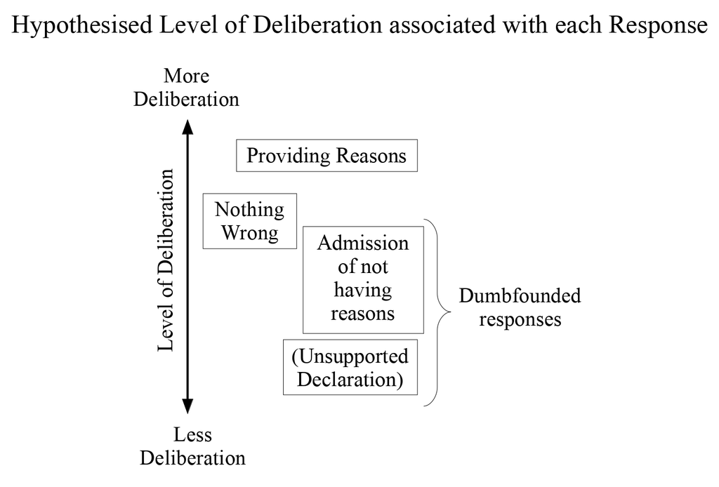

Hypothesised relationship between responses in the dumbfounding paradigm and level of deliberation

### Competing Intuitions

The only response that can be positioned as habitual or deliberative with any confidence is (1) a reason response, which is certainly deliberative, as it illustrates successful deliberation such that two competing intuitions may be aligned. The relative roles of intuition and deliberation in each of the other responses are less clear. There are at least two competing intuitions that may give rise to the remaining responses: (i) that the behaviour is wrong, and (ii) that moral judgements should be grounded in reasons.

Furthermore, (3b) unsupported declaration is a clear endorsing of the first intuition (i) that the behaviour is wrong over the second intuition (ii) that moral judgements should be grounded in reasons. Arriving at this response is possible without deliberation. If a person does not see a need for judgements to be justified by reasons, they are unlikely to engage in a deliberative search for reasons.

The remaining responses (2) nothing wrong and (3a) admission, may be viewed as instances of selecting one of the competing intuitions following deliberation. Providing response (2) nothing wrong, may also be viewed as selecting one of the competing intuitions based on, and informed by deliberation, acknowledging the value of this deliberation process. For this reason it is possible that response (2) nothing wrong, may, in some cases, involve slightly more deliberation than (3a) an admission. The relative level of deliberation involved in (2) nothing wrong and (3a) admission, may vary depending on the individual. Some people may readily change their judgement based on new information, while others may not see the need to justify their judgement by reasons.

In view of the above discussion, the responses may be (tentatively) ranked in order of the relative role of deliberation. Beginning with the highest level of deliberation and ending with the lowest, the responses may be ranked as follows: (i) providing reasons (successful deliberation), (ii) accepting the counter-arguments and rating the behaviour as “not wrong” (failed deliberation/deliberation over-riding an initial intuition), (iii) an admission of not having reasons (failed deliberation/rejection of value of deliberation) and, (iv) an unsupported declaration (failed deliberation/rejection of value of deliberation/deliberation absent). As noted previously, providing reasons is the only response for which claims regarding the relative role of deliberation and intuition can be made with any degree of certainty.

# Influences on Moral Dumbfounding

One prediction of explaining dumbfounding as conflict in dual-processes is that under specific manipulations, responses in the moral dumbfounding paradigm should vary in predictable ways. In addition to external manipulation, a second prediction of this conflict in dual-processes explanation is that responses in the moral dumbfounding paradigm may display variability that can be linked to specific individual difference variables. The studies described here aim to investigate both of these possibilities.

## Influencing Moral Dumbfounding through Experimental Manipulation

Cognitive load has been shown to inhibit deliberative responding (e.g., De Neys, 2006; Evans & Curtis-Holmes, 2005; Evans & Stanovich, 2013; Schmidt, 2016). Above, we identified providing reasons as involving more deliberation than alternative responses in the dumbfounding paradigm. This implies that cognitive load should inhibit the identification of reasons for a judgement, leading to an increase in dumbfounded responding or an increase in accepting the counter-arguments and revising the judgement made.

According to Greene, Morelli, Lowenberg, Nystrom, & Cohen (2008), cognitive load reduces the likelihood of utilitarian judgements but not deontological judgements. The judgements in dumbfounding paradigms are typically deontological; the moral violations described in the scenarios in studies of moral dumbfounding are violations of widely accepted deontic propositions. Changing a judgement in the dumbfounding paradigm means rejecting a deontological judgement in favour of a judgement informed by a utilitarian position (the counter-arguments highlight the lack of harm in the scenarios). Drawing on Greene, Morelli, Lowenberg, Nystrom, & Cohen (2008), who showed that utilitarian judgements are negatively influenced by cognitive load, it is expected that cognitive load should led to more dumbfounded responding, rather than changing of judgements. This prediction is also purported to be supported by Haidt, Björklund, & Murphy (2000). In the opening note of the original Haidt, Björklund, & Murphy (2000) report, they report that they conducted a second study in which they manipulated cognitive load. They report that they found that cognitive load led to increased levels of dumbfounding but did not influence judgements made. Beyond a brief mention in the opening note, this cognitive load and moral dumbfounding study is not reported in full in Haidt, Björklund, & Murphy (2000) or elsewhere.

An investigation of the dumbfounding under cognitive load can test two predictions of dual-process models of moral judgement. Firstly, it is hypothesised that deliberative responding generally will be inhibited by cognitive load, leading to less identification of reasons for judgements. This inhibition may result in higher rates of selecting “there is nothing wrong” or higher rates of dumbfounded responding (or both). However, adopting the work by Greene, Morelli, Lowenberg, Nystrom, & Cohen (2008) suggests that the inhibition of deliberation should result in higher rates of dumbfounded responding only.

Again, there are three possible responses in the dumbfounding paradigm: (1) providing reasons; (2) a change in judgement; and (3) a dumbfounded response. Providing reasons has been identified as requiring more deliberation than the other responses, and as such the introduction of a cognitive load manipulation should reduce the providing of reasons in favour of one of the other responses. It is not clear whether participants would be more likely to revise their judgement or provide a dumbfounded response.

## Individual Differences in Moral Dumbfounding

As noted above, it is likely that responses in the dumbfounding paradigm will vary depending on individual differences. One individual difference variable linked to dual-process approaches to cognition, therefore may be related to susceptibility to dumbfounding is Need for Cognition (Cacioppo & Petty, 1982; Forsterlee & Ho, 1999; Petty, Cacioppo, & Kao, 1984; Petty, Feinstein, Blair, & Jarvis, 1996). The Need for Cognition Scale (NFC) is a measure of an individual’s tendency “to engage in and enjoy effortful analytic activity” (Forsterlee & Ho, 1999, p. 471; see also Cacioppo & Petty, 1982). In other words, it measures a tendency to engage in deliberation (Evans & Stanovich, 2013). It is also related to a person’s need to understand and make sense of the world (Forsterlee & Ho, 1999). It is hypothesised that people who score highly on the NFC will be more likely to provide reasons for their judgement. Related to this, people who score low on the NFC are likely to fail to identify reasons for their judgement. That NFC is related to a need to understand and make sense of the world suggests that of the people who fail to identify reasons for their judgement, the people who revise their judgement will likely score higher on the NFC than people who provide a dumbfounded response.

# The Current Studies

The studies described here aim to investigate test three predictions of a conflict in dual-process explanation of moral dumbfounding. To test the first two predictions we experimentally manipulated cognitive load. Our primary prediction is that a cognitive load manipulation will inhibit people’s ability to provide reasons for their judgement, leading to greater habitual responses (either nothing wrong or dumbfounding or both). A second prediction, informed by Greene, Morelli, Lowenberg, Nystrom, & Cohen (2008), that a cognitive load manipulation will inhibit people’s ability to provide reasons for their judgement, leading to greater dumbfounding specifically will also be tested. The third prediction that will be tested is that a person’s tendency to provide reasons will be related to their score on the Need for Cognition scale (Cacioppo & Petty, 1982; Petty, Cacioppo, & Kao, 1984). We hypothesise that as NFC increases people will be less likely to present as dumbfounded. We conducted five studies to assess these predictions.[^2]<sup>,</sup>[^3] In all five studies, we report all measures, manipulations and exclusions.

```r
large <- pwr.chisq.test(w=.35,df=(3-1),sig.level = .05, power=.8)
med   <- pwr.chisq.test(w=.21,df=(3-1),sig.level = .05, power=.8)
small <- pwr.chisq.test(w=.07,df=(3-1),sig.level = .05, power=.8)

round(large$N)
```

```
## [1] 79
```

```r
# https://www.real-statistics.com/chi-square-and-f-distributions/effect-size-chi-square/
```

```r
small <- powerMediation::SSizeLogisticCon(.2,(1.49), .05, .8)
med <- powerMediation::SSizeLogisticCon(.2,(3.45), .05, .8)
large <- powerMediation::SSizeLogisticCon(.2,(9), .05, .8)
```

# Study 1 - College Sample

The aim of Study 1 was to investigate if a cognitive load manipulation influenced participants’ ability to justify their judgement. We also measured Need for Cognition (Cacioppo & Petty, 1982; Petty, Cacioppo, & Kao, 1984) as a potential moderator variable.

```r
rm(list = ls())

load("loaded_data/one.RData")
df3 <- study_1

df4 <- df3[which(df3$condition=="cog_load"),]
df5 <- df3[which(df3$condition=="control"),]
```

## Study 1: Method

### Participants and design

Study 1 was a between subjects design. The dependent variable was rates of providing reasons/dumbfounding (measured using to the critical slide with 3 response options: 1: providing reasons; 2: there is nothing wrong; 3: dumbfounded response - admission). The independent variable was cognitive load with two levels: present and absent. Cognitive load was manipulated by presenting participants with an eight digit number letter string to be memorised. Need for Cognition (Cacioppo & Petty, 1982; Petty, Cacioppo, & Kao, 1984) was included as a potential correlate and moderator variable.

A total sample of 66 participants (55 female, 11 male; *M*<sub>age</sub> = 22.42, min = 18, max = 57, *SD* = 6.86) took part. Participants in this sample were undergraduate students, postgraduate students, and alumni from Mary Immaculate College (MIC), and University of Limerick (UL). Participation was voluntary and participants were not reimbursed for their participation.

### Procedure and materials

Data were collected using an online questionnaire. Data collection took place in a designated computer laboratory in MIC. The experimenter remained in the laboratory for the duration of the study. Participants were first presented with an information sheet and consent form. The main study proceeded when participants had signed the consent form.

Participants in the experimental condition were presented with an eight digit number/letter string and asked to memorise the sequence. After 30 seconds, the experiment progressed to the next slide. Participants had the option to click “ok” and progress to the next slide after 15 seconds.

Participants were then presented with the “Julie and Mark” (*Incest*) vignette (Haidt, Björklund, & Murphy, 2000). Participants rated on a 7-point Likert scale how right or wrong the behaviour of Julie and Mark was (where, 1 = *Morally wrong*; 4 = *neutral*; 7 = *Morally right*), and were given an opportunity to provide reasons for their judgement. Following this, participants were presented with a series of counter-arguments, which refuted commonly used justifications for rating the behaviour as “wrong.”

Dumbfounding was measured using the critical slide (McHugh, McGann, Igou, & Kinsella, 2017). This contained a statement defending the behaviour and a question as to how the behaviour could be wrong (“Julie and Mark’s behaviour did not harm anyone, how can there be anything wrong with what they did?”). There were three possible answer options: (a) “There is nothing wrong”; (b) an admission of not having reasons (“It’s wrong but I can’t think of a reason”); and finally a judgement with accompanying justification (c) “It’s wrong and I can provide a valid reason.” The order of these response options was randomised. Participants who selected (c) were prompted to type a reason. The selecting of option (b), the admission of not having reasons, was taken to be a dumbfounded response. Following the critical slide, participants in the experimental condition were required to reproduce the eight digit number-letter string sequence presented previously. Following this a post-discussion questionnaire in which participants rated their response to the scenario across various dimensions (Haidt, Björklund, & Murphy, 2000).

Need for Cognition was measured using the short form of the Need for Cognition scale (Cacioppo & Petty, 1982; Petty, Cacioppo, & Kao, 1984). This is an 18 item scale containing questions relating to motivation to engage in thinking (e.g., “I would prefer complex to simple problems”). Responses were recorded on a -4 to +4 Likert-type scale, where -4 = *very strong disagreement* and +4 = *very strong agreement*.

```r
# create variables for reporting t.tests
t <- t.test(df3$InJu1,df3$InJu2, paired = TRUE)

#chisquare test function

custom_chi <- function(x,y){
  a <- length(x)
  b <- length(y)
  c <- rep(1, a)
  d <- rep(2, b)
  e <- c(c,d)
  f <- c(x, y)

  g <- data.frame(e,f)
  h <- table(g$e,g$f)
  suppressWarnings(chisq.test(h))
}

c <- suppressWarnings(custom_chi(df3$InJu1,df3$InJu2))

changed_num <- function(x, judgement_1, judgement_2){
  b <- b <- x[which(x$Ju1_bin==judgement_1 & x$Ju2_bin==judgement_2),]
  length(b$Ju1_bin)

}

tot_changed_num <- function(x, query){

  c <- cbind.data.frame(x$Ju1_bin[which(x$Ju1_bin!=x$Ju2_bin)],x$Ju2_bin[which(x$Ju1_bin!=x$Ju2_bin)])
  colnames(c) <- c("initial_judgement","revised_judgement")

  c
  if(query == "table") print(c)
  if(query == "total") print(length(c$initial_judgement))}
```

```r
sum(df3$InCS!="There is nothing wrong."&df3$Ju1_bin!="wrong")
```

```
## [1] 2
```

```r
t_j1 <- t.test(college$InJu1 ~ college$condition)
d_j1 <- cohensD(college$InJu1 ~ college$condition)

t_paragraph(college$InJu1, college$condition, "initial judgement")
```

```
## [1] An independent samples t-test revealed no difference in initial judgement between the  sample, (M = 2.67, SD = 1.9), and the  sample, (M = 2.09, SD =1.83), t(63.9) = 1.256, p = 0.214.
```

```r
#t_paragraph(one$InJu1, one$condition, "initial judgement")
#t_paragraph(two$InJu1, two$condition, "initial judgement")
#t_paragraph(three$InJu1, three$condition, "initial judgement")

#

c <- chisq.test(table(df3$InCS,df3$condition))
w <- sqrt(c[]$statistic/length(df3$gender))
pw <- pwr.chisq.test(w=w,N=length(df3$InCS),df=(3-1),sig.level = .05)
```

## Study 1: Results

Forty six participants (69.7%) rated the behaviour of Julie and Mark as wrong initially. The mean initial rating of the behaviour was, *M* = 2.38, *SD* = 1.87. There was no difference in initial judgement depending on cognitive load, *t*(63.9040171) = 1.2555553, *p* = .214; *d* = 0.31.

```r
y <- table(df3$condition,df3$InCS)
y <- as.data.frame(y)
colnames(y) <- c("condition","InCS","Freq")

z <- as.data.frame(table(df3$condition,df3$InCS)/length(df3$gender)*2)
perc <- z$Freq
test <- cbind(y,perc)
test$condition
```

```
## [1] cog_load control  cog_load control  cog_load control
## Levels: cog_load control
```

```r
test
```

```
##   condition                                         InCS Freq      perc
## 1  cog_load                      There is nothing wrong.   15 0.4545455
## 2   control                      There is nothing wrong.    5 0.1515152
## 3  cog_load    It's wrong but I can't think of a reason.    6 0.1818182
## 4   control    It's wrong but I can't think of a reason.    7 0.2121212
## 5  cog_load It's wrong and I can provide a valid reason.   12 0.3636364
## 6   control It's wrong and I can provide a valid reason.   21 0.6363636
```

```r
y <- table(df3$condition,df3$Dumb_incl_string)
y <- as.data.frame(y)
colnames(y) <- c("condition","InCS","Freq")




ab_graph <- function(){
  a <- df3[which(df3$condition==levels(as.factor(df3$condition))[1]),]
  b <- df3[which(df3$condition==levels(as.factor(df3$condition))[2]),]
  #levels(as.factor(df3$condition))[1]

  ay <- as.data.frame(table(a$InCS,a$condition))
  by <- as.data.frame(table(b$InCS,b$condition))

  aperc <- ay$Freq/length(a$gender)
  ay <- cbind(ay,aperc)
  colnames(ay) <- c("InCS","condition","Freq","perc")

  bperc <- by$Freq/length(b$gender)
  by <- cbind(by,bperc)
  colnames(by) <- c("InCS","condition","Freq","perc")

  c <- rbind(ay,by)

  c
}

test <- ab_graph()

rm(y)
```

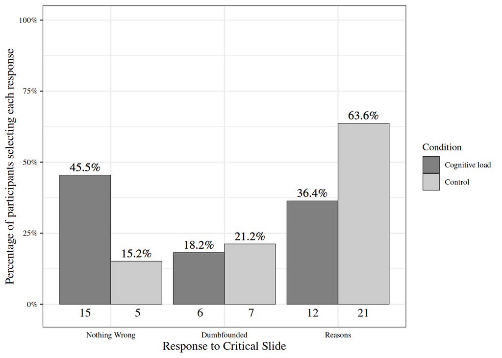

Figure 1: Study 1: Responses to critical slide and for the experimental group (*N* = 33) and the control group (*N* = 33)

```r
ggplot(test, aes(x=InCS, y=perc, fill=factor(condition,labels=c("Cognitive load","Control")))) +
  scale_y_continuous(limits = c(-.03,1),
                     labels = percent_format()
  )+
  geom_col(position = "dodge",
           color="black",
           size=.2
  )+
  geom_text(family = "Times", size=4.2,
            aes( label = scales::percent(test$perc),
                 y= perc ),
            stat= "identity",
            vjust = -.5,
            position = position_dodge(.9),
            fontface='plain'
            )+
  geom_text(family = "Times", size=4.2,
            aes(label = format(Freq),
                y= -3*(..count../100)/(..count..)),
            stat= "count",
            position = position_dodge(0.9),
            #vjust = -.05,
            fontface='plain'
            ) +
  xlab("Response to Critical Slide") +
  ylab("Percentage of participants selecting each response")+
  scale_x_discrete(labels=c("Nothing Wrong", "Dumbfounded","Reasons")) +
  scale_fill_grey(start = .5, end = .8) +
  labs(fill="Condition") +

  geom_text(family = "Times", size=4.2,
            aes( label = scales::percent(test$perc),
                 y= test$perc ),
            stat= "identity",
            vjust = -.5,
            position = position_dodge(.9),
            fontface='plain'
            )+
  #theme_apa() +
  theme_bw() +
  theme(plot.title=element_text(family="Times",
                                size=12
                                ),
        legend.text=element_text(family="Times",
                                 size=8
                                 ),
          legend.title=element_text(family="Times",
                                    size=10
                                    ),
          axis.text=element_text(family="Times",
                                 colour = "black",
                                 size=8
                                 ),
          axis.ticks.x = element_blank(),
          axis.title=element_text(family="Times",
                                  size=12
                                  ),
          strip.text=element_text(family = "Times",
                                  size = 12
                                  ),
          strip.background = element_rect(fill = "white"),
          legend.position="right")
```

```r
c <- chisq.test(table(df3$InCS,df3$condition))
rownames(rbind(c$observed,c$expected,c$stdres))
```

```
## [1] "There is nothing wrong."
## [2] "It's wrong but I can't think of a reason."
## [3] "It's wrong and I can provide a valid reason."
## [4] "There is nothing wrong."
## [5] "It's wrong but I can't think of a reason."
## [6] "It's wrong and I can provide a valid reason."
## [7] "There is nothing wrong."
## [8] "It's wrong but I can't think of a reason."
## [9] "It's wrong and I can provide a valid reason."
```

```r
ps <- function(y){
  if(as.numeric(sqrt( y*y) ) >3.3) print(paste0(y,"**"), quote = FALSE)
  else if(as.numeric(sqrt( y*y) ) >1.96) print(paste0(y,"*"), quote = FALSE)
  else print(y)}


x <- c$stdres
x <- round(x, digits = 2)

lapply(x, ps)
```

```
## [1] 2.68*
## [1] -0.31
## [1] -2.22*
## [1] -2.68*
## [1] 0.31
## [1] 2.22*
```

```
## [[1]]
## [1] "2.68*"
##
## [[2]]
## [1] -0.31
##
## [[3]]
## [1] "-2.22*"
##
## [[4]]
## [1] "-2.68*"
##
## [[5]]
## [1] 0.31
##
## [[6]]
## [1] "2.22*"
```

```r
#c$stdres <- round(c$stdres,digits=3)
#c$stdres <- ps(c$stdres)

ps(x[1])
```

```
## [1] 2.68*
```

```r
ps(x[2])
```

```
## [1] -0.31
```

```r
ps(x[3])
```

```
## [1] -2.22*
```

```r
x <- `colnames<-`(
  cbind.data.frame(c(ps(x[1]),ps(x[2]),ps(x[3])),
                   c(ps(x[4]),ps(x[5]),ps(x[6]))),
  c("cog_load","control")
)
```

```
## [1] 2.68*
## [1] -0.31
## [1] -2.22*
## [1] -2.68*
## [1] 0.31
## [1] 2.22*
```

```r
rownames(x) <- row.names(c$observed)

y <- rbind(round(c$observed), round(c$expected, digits = 2))

c(c$stdres[1])
```

```
## [1] 2.678416
```

```r
res <- cbind(c("Observed count","","","Expected count","","","Standardised residuals","",""),
      c("Nothing Wrong","Dumbfounded","Reasons",
        "Nothing Wrong","Dumbfounded","Reasons",
        "Nothing Wrong","Dumbfounded","Reasons"),
      rbind(y,x)

      )

row.names(res) <- NULL
colnames(res) <- c("","","Cognitive Load","Control")
```

```r
apa_table(
   res
   , align = c("l", "l", "c", "c", "c")
   , caption = "Study 1 – Observed counts, expected counts, and standardised residuals for each response to the critical slide depending on cognitive load"
   #, added_stub_head = "Response to critical slide"
   #, col_spanners = makespanners()
   , note = "* = sig. at \\emph{p} < .05; ** = sig. at \\emph{p} < .001"
   , escape = FALSE

)
```

Table 1:

*Study 1 – Observed counts, expected counts, and standardised residuals for each response to the critical slide depending on cognitive load*

|  |  | Cognitive Load | Control |
| --- | --- | --- | --- |
| Observed count | Nothing Wrong | 15 | 5 |
|  | Dumbfounded | 6 | 7 |
|  | Reasons | 12 | 21 |
| Expected count | Nothing Wrong | 10 | 10 |
|  | Dumbfounded | 6.5 | 6.5 |
|  | Reasons | 16.5 | 16.5 |
| Standardised residuals | Nothing Wrong | 2.68* | -2.68* |
|  | Dumbfounded | -0.31 | 0.31 |
|  | Reasons | -2.22* | 2.22* |

*Note.* * = sig. at < .05; ** = sig. at < .001

Participants who selected the admission of not having reasons on the critical slide were identified as dumbfounded. Thirteen participants (19.7%) selected “It’s wrong but I can’t think of a reason.” Thirty three participants (50%) selected “It’s wrong and I can provide a valid reason”; and twenty participants (30.3%) selected “There is nothing wrong.”

### Cognitive load manipulation check

Analysis of the responses to the cognitive load manipulation revealed that nine participants (27.27%) successfully remembered the sequence of numbers and letters in full. Responses to the manipulation check question revealed that five participants (15.15%) found the memory task easy. Of these, four participants both found the task easy and got the answer right. All participants correctly remembered at least two digits, indicating at least some level of engagement with the cognitive load manipulation.

### Cognitive load and dumbfounded responding

```r
df3$InCS <- relevel(df3$InCS, ref = 2)

df3a <- mlogit.data(df3, choice = "InCS", shape = "wide")
InCSModel<-mlogit(InCS ~ 1 | condition+NFC, data = df3a, reflevel = "It's wrong and I can provide a valid reason."
                  )

summary_InCS_model <- summary(InCSModel)
summary_InCS_model$lratio$parameter
```

```
## df
##  4
```

```r
summary_InCS_model$lratio$statistic
```

```
## 'log Lik.' 12.51638 (df=6)
```

```r
summary_InCS_model$lratio$p.value
```

```
## 'log Lik.' 0.0138973 (df=6)
```

```r
InCSModel$coefficients[3]
```

```
## conditioncontrol:It's wrong but I can't think of a reason.
##                                                 -0.5245397
```

```r
InCSModel$coefficients[4]
```

```
## conditioncontrol:There is nothing wrong.
##                                -1.662828
```

```r
cox <- PseudoR2(multinom(InCS~condition+NFC,df3), "all")
cox[3]
```

```
##  CoxSnell
## 0.1727449
```

```r
cox[4]
```

```
## Nagelkerke
##  0.1980715
```

```r
#PseudoR2(x, "all")
#summary_InCS_model


wald1 <-
  summary_InCS_model$CoefTable[3]^2 /
  summary_InCS_model$CoefTable[7]^2

wald2 <-
  summary_InCS_model$CoefTable[4]^2 /
  summary_InCS_model$CoefTable[8]^2


summary_InCS_model
```

```
##
## Call:
## mlogit(formula = InCS ~ 1 | condition + NFC, data = df3a, reflevel = "It's wrong and I can provide a valid reason.",
##     method = "nr")
##
## Frequencies of alternatives:choice
## It's wrong and I can provide a valid reason.
##                                      0.50000
##    It's wrong but I can't think of a reason.
##                                      0.19697
##                      There is nothing wrong.
##                                      0.30303
##
## nr method
## 4 iterations, 0h:0m:0s
## g'(-H)^-1g = 3.76E-07
## gradient close to zero
##
## Coefficients :
##                                                             Estimate Std. Error
## (Intercept):It's wrong but I can't think of a reason.      -0.537838   0.532399
## (Intercept):There is nothing wrong.                         0.235008   0.430129
## conditioncontrol:It's wrong but I can't think of a reason. -0.524540   0.697788
## conditioncontrol:There is nothing wrong.                   -1.662828   0.634954
## NFC:It's wrong but I can't think of a reason.              -0.658075   0.342920
## NFC:There is nothing wrong.                                -0.020616   0.324945
##                                                            z-value Pr(>|z|)
## (Intercept):It's wrong but I can't think of a reason.      -1.0102 0.312391
## (Intercept):There is nothing wrong.                         0.5464 0.584815
## conditioncontrol:It's wrong but I can't think of a reason. -0.7517 0.452221
## conditioncontrol:There is nothing wrong.                   -2.6188 0.008824 **
## NFC:It's wrong but I can't think of a reason.              -1.9190 0.054980 .
## NFC:There is nothing wrong.                                -0.0634 0.949412
## ---
## Signif. codes:  0 '***' 0.001 '**' 0.01 '*' 0.05 '.' 0.1 ' ' 1
##
## Log-Likelihood: -61.615
## McFadden R^2:  0.092204
## Likelihood ratio test : chisq = 12.516 (p.value = 0.013897)
```

```r
summary_InCS_model$coefficients[3]
```

```
## conditioncontrol:It's wrong but I can't think of a reason.
##                                                 -0.5245397
```

```r
data.frame(exp(InCSModel$coefficients))
```

```
##                                                            exp.InCSModel.coefficients.
## (Intercept):It's wrong but I can't think of a reason.                        0.5840094
## (Intercept):There is nothing wrong.                                          1.2649186
## conditioncontrol:It's wrong but I can't think of a reason.                   0.5918277
## conditioncontrol:There is nothing wrong.                                     0.1896020
## NFC:It's wrong but I can't think of a reason.                                0.5178473
## NFC:There is nothing wrong.                                                  0.9795949
```

```r
exp(InCSModel$coefficients)[3]
```

```
## conditioncontrol:It's wrong but I can't think of a reason.
##                                                  0.5918277
```

```r
a <- exp(confint(InCSModel))
c(a[3],a[7])
```

```
## [1] 0.1507429 1.6580527
```

```r
residuals(InCSModel)
```

```
##  [1] 0.4982061 0.4889026 0.5124570 0.5560019 0.5654635 0.5863437 0.5202814
##  [8] 0.5089043 0.4956082 0.5182328 0.5790962 0.5245696 0.5826844 0.5024738
## [15] 0.6630406 0.8608497 0.2803257 0.8379085 0.8608497 0.7830513 0.7085689
## [22] 0.5721632 0.6084906 0.6065371 0.6009369 0.6027610 0.6606375 0.6281551
## [29] 0.6547118 0.6234499 0.6065371 0.6305820 0.6407947 0.8371752 0.8531789
## [36] 0.8781514 0.8321065 0.8260219 0.7284266 0.7819989 0.8168853 0.6987410
## [43] 0.6509686 0.7941345 0.8693395 0.2709418 0.3402578 0.2829094 0.3543128
## [50] 0.2961991 0.4637055 0.5913954 0.3591981 0.3148073 0.4442484 0.3033684
## [57] 0.3495279 0.3148073 0.2681451 0.2172843 0.3961958 0.3591981 0.4018759
## [64] 0.5620235 0.3797424 0.3033684
```

```r
fitted(InCSModel, outcome = F)
```

```
##    It's wrong and I can provide a valid reason.
## 1                                     0.4091599
## 2                                     0.4205820
## 3                                     0.3934629
## 4                                     0.3510092
## 5                                     0.3423508
## 6                                     0.3236684
## 7                                     0.3853788
## 8                                     0.3972390
## 9                                     0.4122214
## 10                                    0.3874681
## 11                                    0.3300946
## 12                                    0.3810600
## 13                                    0.3269059
## 14                                    0.4042885
```

[output cut: 119 more lines]

```r
c <- summary_InCS_model$lratio$statistic
w <- sqrt(c/length(df3$gender))
pw <- pwr.chisq.test(w=w,N=length(df3$InCS),df=(2),sig.level = .05)

pw$power
```

```
## [1] 0.8966486
```

```r
revised_PseudoR2s <- function(LogModel) {
  dev <- LogModel$deviance
  nullDev <- LogModel$null.deviance
  modelN <- length(LogModel$fitted.values)
  R.l <- 1 - dev / nullDev
  R.cs <- 1- exp ( -(nullDev - dev) / modelN)
  R.n <- R.cs / ( 1 - ( exp (-(nullDev / modelN))))

  all <- list(hosmer_and_lemeshow = as.numeric(R.l), mcfadden = NA, cox_and_snell = as.numeric(R.cs), nagelkerke = as.numeric(R.n))
  all
}

logits_rsquared <- glm(InCS~NFC,df3, family = binomial(link = "logit"))
cox <- revised_PseudoR2s(logits_rsquared)
```

```r
df3$InCS <- relevel(df3$InCS, ref = 2)

df3a <- mlogit.data(df3, choice = "InCS", shape = "wide")
InCSModel<-mlogit(InCS ~ 1 | NFC, data = df3a, reflevel = "It's wrong and I can provide a valid reason.")

summary_InCS_model <- summary(InCSModel)
summary_InCS_model$lratio$parameter
```

```
## df
##  2
```

```r
summary_InCS_model$lratio$statistic
```

```
## 'log Lik.' 4.864398 (df=4)
```

```r
summary_InCS_model$lratio$p.value
```

```
## 'log Lik.' 0.08784346 (df=4)
```

```r
InCSModel$coefficients[3]
```

```
## NFC:It's wrong but I can't think of a reason.
##                                    -0.6258126
```

```r
InCSModel$coefficients[4]
```

```
## NFC:There is nothing wrong.
##                  0.07766466
```

```r
cox <- PseudoR2(multinom(InCS~NFC,df3), "all")
cox[3]
```

```
##   CoxSnell
## 0.07105245
```

```r
cox[4]
```

```
## Nagelkerke
## 0.08146965
```

```r
#PseudoR2(x, "all")
#summary_InCS_model


wald1 <-
  summary_InCS_model$CoefTable[3]^2 /
  summary_InCS_model$CoefTable[7]^2

wald2 <-
  summary_InCS_model$CoefTable[4]^2 /
  summary_InCS_model$CoefTable[8]^2


summary_InCS_model
```

```
##
## Call:
## mlogit(formula = InCS ~ 1 | NFC, data = df3a, reflevel = "It's wrong and I can provide a valid reason.",
##     method = "nr")
##
## Frequencies of alternatives:choice
## It's wrong and I can provide a valid reason.
##                                      0.50000
##    It's wrong but I can't think of a reason.
##                                      0.19697
##                      There is nothing wrong.
##                                      0.30303
##
## nr method
## 4 iterations, 0h:0m:0s
## g'(-H)^-1g = 5.17E-07
## gradient close to zero
##
## Coefficients :
##                                                        Estimate Std. Error
## (Intercept):It's wrong but I can't think of a reason. -0.852771   0.342751
## (Intercept):There is nothing wrong.                   -0.537828   0.319462
## NFC:It's wrong but I can't think of a reason.         -0.625813   0.333382
## NFC:There is nothing wrong.                            0.077665   0.302958
##                                                       z-value Pr(>|z|)
## (Intercept):It's wrong but I can't think of a reason. -2.4880  0.01285 *
## (Intercept):There is nothing wrong.                   -1.6835  0.09227 .
## NFC:It's wrong but I can't think of a reason.         -1.8772  0.06050 .
## NFC:There is nothing wrong.                            0.2564  0.79768
## ---
## Signif. codes:  0 '***' 0.001 '**' 0.01 '*' 0.05 '.' 0.1 ' ' 1
##
## Log-Likelihood: -65.441
## McFadden R^2:  0.035834
## Likelihood ratio test : chisq = 4.8644 (p.value = 0.087843)
```

```r
summary_InCS_model$coefficients[3]
```

```
## NFC:It's wrong but I can't think of a reason.
##                                    -0.6258126
```

```r
data.frame(exp(InCSModel$coefficients))
```

```
##                                                       exp.InCSModel.coefficients.
## (Intercept):It's wrong but I can't think of a reason.                   0.4262322
## (Intercept):There is nothing wrong.                                     0.5840154
## NFC:It's wrong but I can't think of a reason.                           0.5348267
## NFC:There is nothing wrong.                                             1.0807602
```

```r
exp(InCSModel$coefficients)[3]
```

```
## NFC:It's wrong but I can't think of a reason.
##                                     0.5348267
```

```r
a <- exp(confint(InCSModel))
c(a[3],a[7])
```

```
## [1] 0.2782515 1.0279891
```

```r
residuals(InCSModel)
```

```
##  [1] 0.6400359 0.6237959 0.6604988 0.7094809 0.7187227 0.7380529 0.6704229
##  [8] 0.6557339 0.6358151 0.6678917 0.7314906 0.6755872 0.7347576 0.6465825
## [15] 0.8008107 0.8564064 0.2678517 0.8325402 0.8564064 0.7755686 0.6985583
## [22] 0.4442889 0.4636598 0.4621171 0.4579315 0.4592544 0.5154687 0.4811302
## [29] 0.5088221 0.4766660 0.4621171 0.4834927 0.4938347 0.6729880 0.7218682
## [36] 0.7829463 0.6533994 0.6218809 0.7353634 0.7879703 0.8221469 0.7061476
## [43] 0.6590322 0.7998663 0.8734102 0.4533282 0.4859435 0.4579315 0.4938347
## [50] 0.4636598 0.5630285 0.6544993 0.4966472 0.4725425 0.5499441 0.4669750
## [57] 0.4911137 0.4725425 0.4523421 0.4446950 0.5189320 0.4966472 0.5224884
## [64] 0.6327121 0.5088221 0.4669750
```

```r
fitted(InCSModel, outcome = F)
```

```
##    It's wrong and I can provide a valid reason.
## 1                                     0.5485811
## 2                                     0.5538784
## 3                                     0.5378829
## 4                                     0.4974512
## 5                                     0.4879013
## 6                                     0.4662878
## 7                                     0.5312498
## 8                                     0.5407456
## 9                                     0.5502448
## 10                                    0.5330250
## 11                                    0.4738624
## 12                                    0.5274575
## 13                                    0.4701209
## 14                                    0.5456212
```

[output cut: 119 more lines]

```r
c <- summary_InCS_model$lratio$statistic
w <- sqrt(c/length(df3$gender))
pw <- pwr.chisq.test(w=w,N=length(df3$InCS),df=(2),sig.level = .05)

pw$power
```

```
## [1] 0.4921256
```

```r
revised_PseudoR2s <- function(LogModel) {
  dev <- LogModel$deviance
  nullDev <- LogModel$null.deviance
  modelN <- length(LogModel$fitted.values)
  R.l <- 1 - dev / nullDev
  R.cs <- 1- exp ( -(nullDev - dev) / modelN)
  R.n <- R.cs / ( 1 - ( exp (-(nullDev / modelN))))

  all <- list(hosmer_and_lemeshow = as.numeric(R.l), mcfadden = NA, cox_and_snell = as.numeric(R.cs), nagelkerke = as.numeric(R.n))
  all
}

logits_rsquared <- glm(InCS~NFC,df3, family = binomial(link = "logit"))
cox <- revised_PseudoR2s(logits_rsquared)
```

### Need for Cognition

A multinomial logistic regression revealed no significant association between Need for Cognition and response to the critical slide, $\chi$<sup>2</sup>(2, *N* = 66) = 4.86, *p* = .088, the observed power was 0.49.[^4]

```r
df3 <- df3[which(is.na(df3$NFC)==FALSE),]

x <- df3$NFC
y <- as.numeric(df3$InCS)

m1 <- multinom(y ~ x)
```

```r
# summary(m1)
newdata <- data.frame(x = seq(min(x), max(x), length.out = 100))
p1 <- predict(m1, newdata, type = "class")
p2 <- predict(m1, newdata, type = "probs")


logit_plot <- cbind.data.frame(newdata,p2)

logit_plot <- `colnames<-`(logit_plot, c("x","one_l","two_l","three_l"))
logit_plot <- melt(logit_plot, id="x")
```

## Study 1: Discussion

The aim of the Study 1 was to investigate if dumbfounded responding was influenced by cognitive load. Specifically, adopting a dual-systems model of moral judgement, it was hypothesised that cognitive load would lead to reduced levels of deliberative responding, and that a reduction in rates of successfully identifying reasons for judgements would be observed. This may lead to (a) increased levels of dumbfounding, or (b) increased selecting of the “nothing wrong” response. As predicted we found lower rates of providing reasons in the cognitive load group than in the control group. This led to higher rates of selecting “there is nothing wrong” in the cognitive load group.

As discussed above, we hypothesised that moral dumbfounding occurs when people fail to resolve a conflict between an initial intuition and an intuition that emerges following deliberation. Under cognitive load a higher proportion of participants failed to provide reasons for their judgements, and a higher proportion of participants selected the “There’s nothing wrong” response. There was no difference in rates of dumbfounding between the cognitive load group and the control group. It appears that when faced with an inability to justify a judgement with reasons, it is preferable to revise the judgement than to acknowledge the inconsistencies in the form of a dumbfounded response.

# Study 2 - Online Replication

Study 1 demonstrated interesting variability in responses to the critical slide depending on cognitive load. The aim of Study 2 was to assess the replicability of the results of Study 1, using an online sample. In Study 1, the experimenter was in the room with the participants. This made it more difficult for participants to cheat on the memory task. This is not possible with an online sample. An alternative cognitive load manipulation was taken from De Neys and Schaeken (De Neys & Schaeken, 2007), whereby a dot pattern is briefly presented to participants, and participants are required to reproduce the dot pattern at a later stage.

```r
#### load data set 1 ####

rm(list = ls())

load("loaded_data/two.RData")
df3 <- study_2
```

## Study 2: Method

### Participants and design

Study 2 was a between subjects design. The dependent variable was response to the critical slide. The independent variable was cognitive load with two levels: high and low. Need for Cognition (Cacioppo & Petty, 1982; Petty, Cacioppo, & Kao, 1984) was included as a potential correlate and moderator variable.

A total sample of 100 participants (56 female, 44 male; *M*<sub>age</sub> = 38.38, min = 19, max = 72, *SD* = 12.41) took part. Participants in this sample were recruited using Amazon’s MTurk (Amazon Web Services Inc., 2016). Participants were paid $0.50 for their participation. Participants were recruited from English speaking countries or from countries where residents generally have a high level of English (e.g., The Netherlands, Denmark, Sweden).

### Procedure and materials

Data were collected using an online questionnaire. Materials were largely the same as in Study 1, with a change to the cognitive load manipulation. Cognitive load was manipulated using a dot-pattern memory task (De Neys & Schaeken, 2007).

Participants were presented with a 3 x 3 grid containing a dot pattern. This image disappeared after one second. Participants then answered a question relating to the moral judgement task. Following this, participants were asked to reproduce the dot-pattern. All participants took part in the memory task, and cognitive load was manipulated by varying the complexity of the patterns presented (De Neys & Schaeken, 2007). The control group were presented with simple patterns, containing three dots in a line, while the experimental group were presented with more complex dot patterns containing 4 dots, see Figure 2.

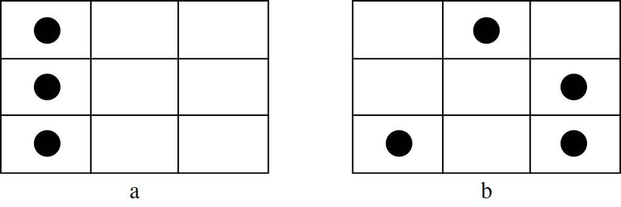

Figure 2: Sample dot patterns - more simple for the control group (a) and higher complexity for the experimental condition (b)

```r
x <- c(10,20,30,30)
y <- c(10,30,10,20)
x <- x - 5
y <- y - 5



#rbind(x,y)
z <- cbind.data.frame(x,y)
z$diff <- rep("b",length=length(z$x))

x <- c(10,10,10)
y <- c(10,20,30)
x <- x - 5
y <- y - 5



#rbind(x,y)
z2 <- cbind.data.frame(x,y)
z2$diff <- rep("a",length=length(z2$x))

z3 <- rbind(z,z2)
#z3
#rm(g)
ggplot(z3, aes(x=x,y=y)) +
 geom_point(size=8) +
 xlab(NULL) + ylab(NULL) +
 scale_x_continuous(breaks = c(10,20),
                            labels = NULL, limits = c(1, 29)) +
#g <- g + scale_x_continuous(breaks = c(0,10,20,30), labels = NULL, limits = c(0, 30))
 scale_y_continuous(breaks = c(10,20),
                            labels = NULL, limits = c(1, 29))+
  facet_grid(.~diff,switch = 'x')+
 theme(plot.title=element_text(family="Times", size=12),
               legend.text=element_text(family="Times", size=8),
               legend.title=element_text(family="Times", size=12),
               axis.text=element_text(family="Times", size=8),
               axis.title=element_text(family="Times", size=12),
               panel.background = element_rect(fill = "white",
                                               colour = NA),
               panel.border = element_rect(fill = NA, size = 1,
                                           colour = "black"),
               panel.grid.major = element_line(colour = "black"),
               panel.grid.minor = element_line(colour = "white",
                                               size = 0.25),
               axis.ticks.length = unit(0,"cm"),
       plot.margin = NULL,
       strip.background = element_rect(fill = NA, size = 1,
                                           colour = "white"),
       strip.text = element_text(family = "Times",size = 16),
       panel.spacing = unit(4, "lines"))
```

Study 2 proceeded in much the same way as Study 1. There were four target questions during which participants were engaged in the memory task. A different pattern was presented before each of the following: the initial judgement, the initial opportunity to provide reasons, the critical slide, and the revised judgement. After each of these questions participants were required to reproduce the pattern. As in Study 1, dumbfounding was measured using the critical slide.

## Study 2: Results

```r
sum(df3$InCS!="There is nothing wrong."&df3$Ju1_bin!="wrong")
```

```
## [1] 6
```

```r
t_j1 <- t.test(df3$InJu1 ~ df3$condition)
d_j1 <- cohensD(df3$InJu1 ~ df3$condition)
#t_j1 <- t.test(college$InJu1 ~ college$condition)
#t_paragraph(college$InJu1, college$condition, "initial judgement")
#t_paragraph(one$InJu1, one$condition, "initial judgement")
#t_paragraph(two$InJu1, two$condition, "initial judgement")
#t_paragraph(three$InJu1, three$condition, "initial judgement")

#

c <- chisq.test(table(df3$InCS,df3$condition))
w <- sqrt(c[]$statistic/length(df3$gender))
pw <- pwr.chisq.test(w=w,N=length(df3$InCS),df=(3-1),sig.level = .05)
```

Seventy seven participants (77%) rated the behaviour of Julie and Mark as wrong initially. The mean initial rating of the behaviour was, *M* = 2.13, *SD* = 1.54. There was no difference in initial judgement depending on cognitive load, *t*(97.7705756) = 0.9617044, *p* = .339; *d* = 0.19.

Participants who selected the admission of not having reasons on the critical slide were identified as dumbfounded. Twenty six participants (26%) selected “It’s wrong but I can’t think of a reason.” Fifty participants (50%) selected “It’s wrong and I can provide a valid reason”; and twenty four participants (24%) selected “There is nothing wrong.”

### Cognitive load and dumbfounded responding

A chi-squared test for independence revealed no association between experimental condition and response to the critical slide, $\chi$<sup>2</sup>(2, *N* = 100) = 0.742, *p* = .690, *V* = 0.0861596, the observed power was 0.110112. The responses to the critical slide for the experimental group (*N* = 51) and the control group (*N* = 49) are displayed in Figure 3.

```r
y <- table(df3$InCS,df3$condition)
#y <- table(df3$InCS,df3$engaged)
y <- as.data.frame(y)
#colnames(y) <- c("condition","InCS","Freq")
colnames(y) <- c("InCS","condition","Freq")

z <- as.data.frame(table(df3$condition,df3$InCS)/length(df3$gender)*2)

z <- rbind(as.data.frame(table(df3$InCS[which(df3$condition=="cog_load")])/
                           length(df3$InCS[which(df3$condition=="cog_load")])),
           as.data.frame(table(df3$InCS[which(df3$condition=="control")])/
                           length(df3$InCS[which(df3$condition=="control")])))



perc <- z$Freq
test <- cbind(y,perc)



#
# y <- table(df3$condition,df3$Dumb_incl_string)
# y <- as.data.frame(y)
 colnames(y) <- c("InCS","condition","Freq")

# z <- as.data.frame(table(df3$condition,df3$Dumb_incl_string)/length(df3$gender)*2)
# perc <- z$Freq
# test <- cbind(y,perc)
# test$condition
# test



ab_graph <- function(){
  a <- df3[which(df3$condition==levels(as.factor(df3$condition))[1]),]
  b <- df3[which(df3$condition==levels(as.factor(df3$condition))[2]),]
  #levels(as.factor(df3$condition))[1]

  ay <- as.data.frame(table(a$InCS,a$condition))
  by <- as.data.frame(table(b$InCS,b$condition))

  aperc <- ay$Freq/length(a$gender)
  ay <- cbind(ay,aperc)
  colnames(ay) <- c("InCS","condition","Freq","perc")

  bperc <- by$Freq/length(b$gender)
  by <- cbind(by,bperc)
  colnames(by) <- c("InCS","condition","Freq","perc")

  c <- rbind(ay,by)

  c
}

test <- ab_graph()


rm(x,y)
```

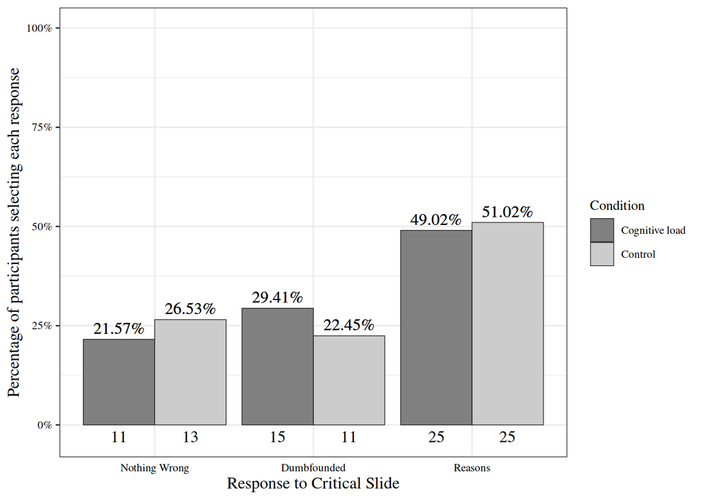

Figure 3: Study 2: Responses to critical slide for the experimental group (*N* = 51) and the control group (*N* = 49)

```r
ggplot(test, aes(x=InCS, y=perc, fill=factor(condition,labels=c("Cognitive load","Control")))) +
  scale_y_continuous(limits = c(-.03,1),
                     labels = percent_format()
  )+
  geom_col(position = "dodge",
           color="black",
           size=.2
  )+
  geom_text(family = "Times", size=4.2,
            aes( label = scales::percent(test$perc),
                 y= perc ),
            stat= "identity",
            vjust = -.5,
            position = position_dodge(.9),
            fontface='plain'
            )+
  geom_text(family = "Times", size=4.2,
            aes(label = format(Freq),
                y= -3*(..count../100)/(..count..)),
            stat= "count",
            position = position_dodge(0.9),
            #vjust = -.05,
            fontface='plain'
            ) +
  xlab("Response to Critical Slide") +
  ylab("Percentage of participants selecting each response")+
  scale_x_discrete(labels=c("Nothing Wrong", "Dumbfounded","Reasons")) +
  scale_fill_grey(start = .5, end = .8) +
  labs(fill="Condition") +

  geom_text(family = "Times", size=4.2,
            aes( label = scales::percent(test$perc),
                 y= test$perc ),
            stat= "identity",
            vjust = -.5,
            position = position_dodge(.9),
            fontface='plain'
            )+
  #theme_apa() +
  theme_bw() +
  theme(plot.title=element_text(family="Times",
                                size=12
                                ),
        legend.text=element_text(family="Times",
                                 size=8
                                 ),
          legend.title=element_text(family="Times",
                                    size=10
                                    ),
          axis.text=element_text(family="Times",
                                 colour = "black",
                                 size=8
                                 ),
          axis.ticks.x = element_blank(),
          axis.title=element_text(family="Times",
                                  size=12
                                  ),
          strip.text=element_text(family = "Times",
                                  size = 12
                                  ),
          strip.background = element_rect(fill = "white"),
          legend.position="right")
```

```r
#rm(a,b,c)
#
# g <- ggplot(df3, aes(x=InCS, fill=factor(condition,labels=c("Cognitive load","Control"))))
# g <- g + geom_bar(aes(y=..count..), position = position_dodge(), color="black")
# g <- g + xlab("Response to critical slide")
# #g <- g + ggtitle("Dumbfounding and Cognitive load")
# g <- g + scale_x_discrete(labels=c("nothing wrong", "no reason", "valid reason"))
# g <- g + scale_fill_grey(start = .5, end = .8)+ theme_bw()
# g <- g + labs(fill="Condition")
# #grid.gedit("GRID.text",gp=gpar(fontfamily="serif"))
# g <- g + geom_text(family = "Times", aes(label = format(..count..),y= ..count.. ), stat= "count", vjust = 1.6, position = position_dodge(0.9))
#
# g + theme(plot.title=element_text(family="Times", size=12), legend.text=element_text(family="Times", size=8), legend.title=element_text(family="Times", size=12), axis.text=element_text(family="Times", size=8), axis.title=element_text(family="Times", size=12))
# rm(g)

df4 <- df3[which(df3$engaged=="engaged"),]
df5 <- df3[which(df3$engaged=="not engaged"),]

# table(df3$InCS,df3$engaged)
```

### Engagement with the Memory Task

```r
df3 <- one

#y <- table(df3$InCS,df3$condition)
y <- table(df3$InCS,df3$engaged)
y <- as.data.frame(y)
#colnames(y) <- c("condition","InCS","Freq")
colnames(y) <- c("InCS","condition","Freq")

z <- as.data.frame(table(df3$condition,df3$InCS)/length(df3$gender)*2)



z <- rbind(as.data.frame(table(df3$InCS[which(df3$engaged=="engaged")])/
                           length(df3$InCS[which(df3$engaged=="engaged")])),
           as.data.frame(table(df3$InCS[which(df3$engaged=="not engaged")])/
                           length(df3$InCS[which(df3$engaged=="not engaged")])))


perc <- z$Freq
test <- cbind(y,perc)
```

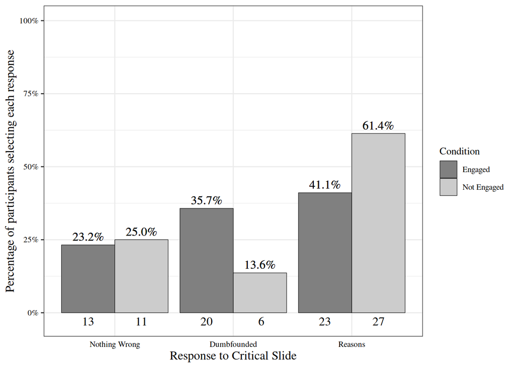

Figure 4: Study 2: Responses to critical slide depending on engagement (*N* = 56) or non-engagement (*N* = 44) with the memory task

```r
ggplot(test, aes(x=InCS, y=perc, fill=factor(condition,labels=c("Engaged","Not Engaged")))) +
  scale_y_continuous(limits = c(-.03,1),
                     labels = percent_format()
  )+
  geom_col(position = "dodge",
           color="black",
           size=.2
  )+
  geom_text(family = "Times", size=4.2,
            aes( label = scales::percent(test$perc),
                 y= perc ),
            stat= "identity",
            vjust = -.5,
            position = position_dodge(.9),
            fontface='plain'
            )+
  geom_text(family = "Times", size=4.2,
            aes(label = format(Freq),
                y= -3*(..count../100)/(..count..)),
            stat= "count",
            position = position_dodge(0.9),
            #vjust = -.05,
            fontface='plain'
            ) +
  xlab("Response to Critical Slide") +
  ylab("Percentage of participants selecting each response")+
  scale_x_discrete(labels=c("Nothing Wrong", "Dumbfounded","Reasons")) +
  scale_fill_grey(start = .5, end = .8) +
  labs(fill="Condition") +

  geom_text(family = "Times", size=4.2,
            aes( label = scales::percent(test$perc),
                 y= test$perc ),
            stat= "identity",
            vjust = -.5,
            position = position_dodge(.9),
            fontface='plain'
            )+
  #theme_apa() +
  theme_bw() +
  theme(plot.title=element_text(family="Times",
                                size=12
                                ),
        legend.text=element_text(family="Times",
                                 size=8
                                 ),
          legend.title=element_text(family="Times",
                                    size=10
                                    ),
          axis.text=element_text(family="Times",
                                 colour = "black",
                                 size=8
                                 ),
          axis.ticks.x = element_blank(),
          axis.title=element_text(family="Times",
                                  size=12
                                  ),
          strip.text=element_text(family = "Times",
                                  size = 12
                                  ),
          strip.background = element_rect(fill = "white"),
          legend.position="right")
```

```r
#rm(a,b,c)
#
# g <- ggplot(df3, aes(x=InCS, fill=factor(condition,labels=c("Cognitive load","Control"))))
# g <- g + geom_bar(aes(y=..count..), position = position_dodge(), color="black")
# g <- g + xlab("Response to critical slide")
# #g <- g + ggtitle("Dumbfounding and Cognitive load")
# g <- g + scale_x_discrete(labels=c("nothing wrong", "no reason", "valid reason"))
# g <- g + scale_fill_grey(start = .5, end = .8)+ theme_bw()
# g <- g + labs(fill="Condition")
# #grid.gedit("GRID.text",gp=gpar(fontfamily="serif"))
# g <- g + geom_text(family = "Times", aes(label = format(..count..),y= ..count.. ), stat= "count", vjust = 1.6, position = position_dodge(0.9))
#
# g + theme(plot.title=element_text(family="Times", size=12), legend.text=element_text(family="Times", size=8), legend.title=element_text(family="Times", size=12), axis.text=element_text(family="Times", size=8), axis.title=element_text(family="Times", size=12))
# rm(g)

#(1-pnorm(3.30))*2
```

```r
c <- chisq.test(table(df3$InCS,df3$engaged))
rownames(rbind(c$observed,c$expected,c$stdres))
```

```
## [1] "There is nothing wrong."
## [2] "It's wrong but I can't think of a reason."
## [3] "It's wrong and I can provide a valid reason."
## [4] "There is nothing wrong."
## [5] "It's wrong but I can't think of a reason."
## [6] "It's wrong and I can provide a valid reason."
## [7] "There is nothing wrong."
## [8] "It's wrong but I can't think of a reason."
## [9] "It's wrong and I can provide a valid reason."
```

```r
ps <- function(y){
  if(as.numeric(sqrt( y*y) ) >3.3) print(paste0(y,"**"), quote = FALSE)
  else if(as.numeric(sqrt( y*y) ) >1.96) print(paste0(y,"*"), quote = FALSE)
  else print(y)}

x <- c$stdres
x <- round(x, digits = 2)

lapply(x, ps)
```

```
## [1] -0.21
## [1] 2.5*
## [1] -2.01*
## [1] 0.21
## [1] -2.5*
## [1] 2.01*
```

```
## [[1]]
## [1] -0.21
##
## [[2]]
## [1] "2.5*"
##
## [[3]]
## [1] "-2.01*"
##
## [[4]]
## [1] 0.21
##
## [[5]]
## [1] "-2.5*"
##
## [[6]]
## [1] "2.01*"
```

```r
#c$stdres <- round(c$stdres,digits=3)
#c$stdres <- ps(c$stdres)

ps(x[1])
```

```
## [1] -0.21
```

```r
ps(x[2])
```

```
## [1] 2.5*
```

```r
ps(x[3])
```

```
## [1] -2.01*
```

```r
x <- `colnames<-`(
  cbind.data.frame(c(ps(x[1]),ps(x[2]),ps(x[3])),
                   c(ps(x[4]),ps(x[5]),ps(x[6]))),
  c("engaged","not engaged")
)
```

```
## [1] -0.21
## [1] 2.5*
## [1] -2.01*
## [1] 0.21
## [1] -2.5*
## [1] 2.01*
```

```r
rownames(x) <- row.names(c$observed)

y <- rbind(round(round(c$observed)), round(c$expected, digits = 2))

c(c$stdres[1])
```

```
## [1] -0.2075486
```

```r
res <- cbind(c("Observed count","","","Expected count","","","Standardised residuals","",""),
      c("Nothing Wrong","Dumbfounded","Reasons",
        "Nothing Wrong","Dumbfounded","Reasons",
        "Nothing Wrong","Dumbfounded","Reasons"),
      rbind(y,x)

      )

row.names(res) <- NULL
colnames(res) <- c("","","Engaged","Not Engaged")
```

```r
apa_table(
   res
   , align = c("l", "l", "c", "c", "c")
   , caption = "Study 2 – Observed counts, expected counts, and standardised residuals for each response to the critical slide depending on cognitive load"
   #, added_stub_head = "Response to critical slide"
   #, col_spanners = makespanners()
   , note = "* = sig. at \\emph{p} < .05; ** = sig. at \\emph{p} < .001"
   , escape = FALSE

)
```

Table 2:

|  |  | Engaged | Not Engaged |
| --- | --- | --- | --- |
| Observed count | Nothing Wrong | 13 | 11 |
|  | Dumbfounded | 20 | 6 |
|  | Reasons | 23 | 27 |
| Expected count | Nothing Wrong | 13.44 | 10.56 |
|  | Dumbfounded | 14.56 | 11.44 |
|  | Reasons | 28 | 22 |
| Standardised residuals | Nothing Wrong | -0.21 | 0.21 |
|  | Dumbfounded | 2.5* | -2.5* |
|  | Reasons | -2.01* | 2.01* |

*Note.* * = sig. at < .05; ** = sig. at < .001

Rates of successful reproduction of the dot patterns in Study 2 were much lower than reported by De Neys and Shaeken (De Neys & Schaeken, 2007). It appears that participants in Study 2 did not engage with the memory task in the same way as participants in De Neys and Shaeken’s studies (De Neys & Schaeken, 2007). We hypothesised that the effectiveness of the cognitive load manipulation may be moderated by the degree to which people engage with the manipulation.

The memory task involved correctly placing dots in a 3 x 3 grid. For the scoring of this task, each of the nine places in the grid could be marked/not marked correctly or incorrectly, making 9 the total possible number of correct responses. If a person misplaced one dot in the pattern this would count for 2 incorrect places in the grid: the mark in the incorrect place, and the absence of a mark in the place it should have been. A participant who received a score of 7, could reasonably be taken to have engaged with the task, and simply made a slip. As such, this was taken as the cut-off point for identifying engagement. This resulted in 56 participants being identified as engaging with the memory task, and 44 being identified as not engaging with the task.

```r
c <- chisq.test(table(df3$InCS,df3$engaged))

w <- sqrt(c[]$statistic/length(df3$gender))
#w <- sqrt(2.464856/120)
pwr.chisq.test(w=w,df=(3-1),N=length(df3$InCS),sig.level = .05)
```

```
##
##      Chi squared power calculation
##
##               w = 0.2584829
##               N = 100
##              df = 2
##       sig.level = 0.05
##           power = 0.6336926
##
## NOTE: N is the number of observations
```

```r
c[]$stdres
```

```
##
##                                                   engaged not engaged
##   There is nothing wrong.                      -0.2075486   0.2075486
##   It's wrong but I can't think of a reason.     2.4984808  -2.4984808
##   It's wrong and I can provide a valid reason. -2.0145574   2.0145574
```

```r
c[]
```

```
## $statistic
## X-squared
##  6.681339
##
## $parameter
## df
##  2
##
## $p.value
## [1] 0.03541323
##
## $method
## [1] "Pearson's Chi-squared test"
##
## $data.name
## [1] "table(df3$InCS, df3$engaged)"
##
## $observed
##
##                                                engaged not engaged
##   There is nothing wrong.                           13          11
##   It's wrong but I can't think of a reason.         20           6
##   It's wrong and I can provide a valid reason.      23          27
##
## $expected
##
##                                                engaged not engaged
##   There is nothing wrong.                        13.44       10.56
##   It's wrong but I can't think of a reason.      14.56       11.44
##   It's wrong and I can provide a valid reason.   28.00       22.00
##
## $residuals
##
##                                                   engaged not engaged
##   There is nothing wrong.                      -0.1200198   0.1354006
##   It's wrong but I can't think of a reason.     1.4256674  -1.6083697
##   It's wrong and I can provide a valid reason. -0.9449112   1.0660036
##
## $stdres
##
##                                                   engaged not engaged
##   There is nothing wrong.                      -0.2075486   0.2075486
##   It's wrong but I can't think of a reason.     2.4984808  -2.4984808
##   It's wrong and I can provide a valid reason. -2.0145574   2.0145574
```

```r
df3$InCS <- relevel(df3$InCS, ref = 2)

df3a <- mlogit.data(df3, choice = "InCS", shape = "wide")
InCSModel<-mlogit(InCS ~ 1 | NFC, data = df3a, reflevel = "It's wrong and I can provide a valid reason.")

summary_InCS_model <- summary(InCSModel)
summary_InCS_model$lratio$parameter
```

```
## df
##  2
```

```r
summary_InCS_model$lratio$statistic
```

```
## 'log Lik.' 2.191697 (df=4)
```

```r
summary_InCS_model$lratio$p.value
```

```
## 'log Lik.' 0.3342558 (df=4)
```

```r
InCSModel$coefficients[3]
```

```
## NFC:It's wrong but I can't think of a reason.
##                                   -0.06818095
```

```r
InCSModel$coefficients[4]
```

```
## NFC:There is nothing wrong.
##                   0.1940487
```

```r
cox <- PseudoR2(multinom(InCS~NFC,df3), "all")
cox[3]
```

```
##   CoxSnell
## 0.02167855
```

```r
cox[4]
```

```
## Nagelkerke
## 0.02477832
```

```r
#PseudoR2(x, "all")
#summary_InCS_model


wald1 <-
  summary_InCS_model$CoefTable[3]^2 /
  summary_InCS_model$CoefTable[7]^2

wald2 <-
  summary_InCS_model$CoefTable[4]^2 /
  summary_InCS_model$CoefTable[8]^2


summary_InCS_model
```

```
##
## Call:
## mlogit(formula = InCS ~ 1 | NFC, data = df3a, reflevel = "It's wrong and I can provide a valid reason.",
##     method = "nr")
##
## Frequencies of alternatives:choice
## It's wrong and I can provide a valid reason.
##                                         0.50
##    It's wrong but I can't think of a reason.
##                                         0.26
##                      There is nothing wrong.
##                                         0.24
##
## nr method
## 4 iterations, 0h:0m:0s
## g'(-H)^-1g = 0.000179
## successive function values within tolerance limits
##
## Coefficients :
##                                                        Estimate Std. Error
## (Intercept):It's wrong but I can't think of a reason. -0.626060   0.248876
## (Intercept):There is nothing wrong.                   -0.875197   0.285079
## NFC:It's wrong but I can't think of a reason.         -0.068181   0.150686
## NFC:There is nothing wrong.                            0.194049   0.166832
##                                                       z-value Pr(>|z|)
## (Intercept):It's wrong but I can't think of a reason. -2.5156  0.01188 *
## (Intercept):There is nothing wrong.                   -3.0700  0.00214 **
## NFC:It's wrong but I can't think of a reason.         -0.4525  0.65093
## NFC:There is nothing wrong.                            1.1631  0.24477
## ---
## Signif. codes:  0 '***' 0.001 '**' 0.01 '*' 0.05 '.' 0.1 ' ' 1
##
## Log-Likelihood: -102.84
## McFadden R^2:  0.010544
## Likelihood ratio test : chisq = 2.1917 (p.value = 0.33426)
```

```r
summary_InCS_model$coefficients[3]
```

```
## NFC:It's wrong but I can't think of a reason.
##                                   -0.06818095
```

```r
data.frame(exp(InCSModel$coefficients))
```

```
##                                                       exp.InCSModel.coefficients.
## (Intercept):It's wrong but I can't think of a reason.                   0.5346944
## (Intercept):There is nothing wrong.                                     0.4167797
## NFC:It's wrong but I can't think of a reason.                           0.9340914
## NFC:There is nothing wrong.                                             1.2141555
```

```r
exp(InCSModel$coefficients)[3]
```

```
## NFC:It's wrong but I can't think of a reason.
##                                     0.9340914
```

```r
a <- exp(confint(InCSModel))
c(a[3],a[7])
```

```
## [1] 0.6952249 1.2550281
```

```r
residuals(InCSModel)
```

```
##   [1] 0.6921338 0.6921338 0.8628470 0.6740147 0.7884538 0.8022529 0.7219144
##   [8] 0.7370905 0.7301597 0.4875668 0.5119136 0.5172308 0.4724436 0.8445424
##  [15] 0.6660933 0.7481845 0.7267109 0.6870106 0.7097108 0.7177083 0.7944492
##  [22] 0.7408013 0.8022529 0.6895777 0.4827995 0.4962912 0.4817369 0.7218541
##  [29] 0.8190176 0.7232372 0.4869254 0.5013684 0.4726516 0.7246208 0.7744326
##  [36] 0.6472716 0.4710209 0.7384773 0.6686429 0.6861811 0.7121754 0.7509567
##  [43] 0.7343175 0.6957178 0.7260049 0.7864283 0.8135566 0.7177083 0.5376814
##  [50] 0.4924249 0.5022611 0.4722471 0.4856816 0.4924249 0.5129510 0.5325480
##  [57] 0.5013684 0.4962912 0.4717255 0.4888890 0.4856816 0.5129510 0.4902638
##  [64] 0.4902638 0.4895699 0.4760613 0.4869254 0.5108892 0.4822618 0.4726516
##  [71] 0.7121754 0.7718712 0.7431053 0.7944492 0.7894604 0.7246208 0.7495708
##  [78] 0.7948761 0.7454114 0.6998224 0.6292002 0.7675512 0.7771774 0.5004891
##  [85] 0.5108892 0.4850793 0.5513363 0.5325480 0.4882214 0.5088796 0.5363800
##  [92] 0.4706170 0.5240360 0.5403198 0.5194481 0.5098778 0.5288256 0.5050184
##  [99] 0.4939317 0.4850793
```

```r
fitted(InCSModel, outcome = F)
```

```
##     It's wrong and I can provide a valid reason.
## 17                                     0.4747853
## 18                                     0.4747853
## 19                                     0.5288138
## 20                                     0.4661867
## 21                                     0.5130746
## 22                                     0.5172005
## 23                                     0.4880864
## 24                                     0.5068283
## 25                                     0.5104301
## 26                                     0.5124332
## 27                                     0.4880864
## 28                                     0.4827692
## 29                                     0.5275564
## 30                                     0.5266553
```

[output cut: 187 more lines]

```r
c <- summary_InCS_model$lratio$statistic
w <- sqrt(c/length(df3$gender))
pw <- pwr.chisq.test(w=w,N=length(df3$InCS),df=(2),sig.level = .05)

pw$power
```

```
## [1] 0.2438852
```

```r
revised_PseudoR2s <- function(LogModel) {
  dev <- LogModel$deviance
  nullDev <- LogModel$null.deviance
  modelN <- length(LogModel$fitted.values)
  R.l <- 1 - dev / nullDev
  R.cs <- 1- exp ( -(nullDev - dev) / modelN)
  R.n <- R.cs / ( 1 - ( exp (-(nullDev / modelN))))

  all <- list(hosmer_and_lemeshow = as.numeric(R.l), mcfadden = NA, cox_and_snell = as.numeric(R.cs), nagelkerke = as.numeric(R.n))
  all
}

logits_rsquared <- glm(InCS~NFC,df3, family = binomial(link = "logit"))
cox <- revised_PseudoR2s(logits_rsquared)
```

### Need for Cognition

A multinomial logistic regression revealed no significant association between Need for Cognition and response to the critical slide, $\chi$<sup>2</sup>(2, *N* = 100) = 2.19, *p* = .334, the observed power was 0.24.[^5]

```r
df3 <- df3[which(is.na(df3$NFC)==FALSE),]

x <- df3$NFC
y <- as.numeric(df3$InCS)

m1 <- multinom(y ~ x)
```

```r
# summary(m1)
newdata <- data.frame(x = seq(min(x), max(x), length.out = 100))
p1 <- predict(m1, newdata, type = "class")
p2 <- predict(m1, newdata, type = "probs")


logit_plot <- cbind.data.frame(newdata,p2)

logit_plot <- `colnames<-`(logit_plot, c("x","one_l","two_l","three_l"))
logit_plot <- melt(logit_plot, id="x")
```

## Study 2: Discussion

The aim of Study 2 was to replicate Study 1. As a replication it failed. However, interesting variability was observed when engagement with the memory task was accounted for. As predicted, under cognitive load (engagement with the memory task) rates of providing reasons were reduced. In contrast to Study 1, the reduced rates of providing reasons led to higher rates of dumbfounded responding (rather than increased rates of selecting “There is nothing wrong”).

Two problems with the cognitive load manipulation were identified. Firstly, the control did not serve as an appropriate control. Secondly, (and unsurprisingly) the manipulation is only effective if participants engage with the memory task. A follow-up study addresses each of these, using no task as the control for the cognitive load manipulation (e.g., Drolet & Frances Luce, 2004), and assessing the responses to the memory task to ensure participants adequately engaged with the load manipulation.

# Study 3 - Revised Online Replication

```r
#### load data set 2 ####
rm(list = ls())

load("loaded_data/three.RData")
df3 <- study_3

a <- sum(df3$engaged==F)

df3 <- df3[which(df3$engaged==T),]
two_e <- df3
```

In Study 2 the role of engagement with the memory task emerged as an important moderator of the effectiveness of the cognitive load manipulation. Study 3 was conducted in order to test if cognitive load affects participants’ ability to identify reasons for their judgements, when accounting for engagement with the memory task.

## Study 3: Methods

### Participants and Design

Study 3 was a between subjects design. The dependent variable was response to the critical slide. The independent variable was cognitive load with two levels: present and absent. Need for Cognition (Cacioppo & Petty, 1982; Petty, Cacioppo, & Kao, 1984) was included as a potential correlate and moderator variable.

Following the elimination of 34 participants who scored less than 7 on the memory task we were left with a final sample of 129 participants (74 female, 55 male; *M*<sub>age</sub> = 40.26, min = 20, max = 72, *SD* = 13.04). Participants in this sample were recruited through MTurk (under the same conditions as Study 2).

### Procedure and Materials

Study 3 was the same as Study 2 with two changes. The control group did not take part in a memory task, and to avoid task fatigue, in the dot patterns presented to the experimental group, the dot patterns presented alternated between the easy 3-dot patterns and the complex 4-dot patterns.

A score of 7 or higher on the memory task that accompanied the critical slide was selected as the measure of engagement with the memory task. Only participants who engaged with the task were eligible for analysis. Other than the two changes described above, Study 3 was the same as Study 2.

## Study 3: Results

```r
#df3 <- df3[which(df3$cog_load_CS_num>7|df3$condition=="control"),]
y <- table(df3$InCS,df3$condition)
y <- as.data.frame(y)
y
```

```
##                                           Var1     Var2 Freq
## 1                      There is nothing wrong. cog_load   15
## 2    It's wrong but I can't think of a reason. cog_load   17
## 3 It's wrong and I can provide a valid reason. cog_load   36
## 4                      There is nothing wrong.  control   15
## 5    It's wrong but I can't think of a reason.  control    5
## 6 It's wrong and I can provide a valid reason.  control   41
```

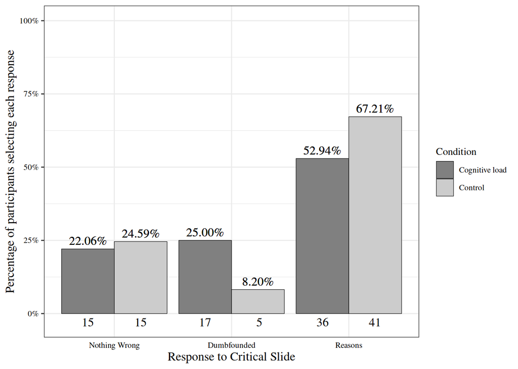

Figure 5: Study 3: Responses to critical slide for the cognitive load group (*N* = 68) and the control group (*N* = 61)

```r
#colnames(y) <- c("condition","InCS","Freq")
colnames(y) <- c("InCS","condition","Freq")

#z <- as.data.frame(table(df3$condition,df3$InCS)/length(df3$gender)*2)

z <- rbind(as.data.frame(table(df3$InCS[which(df3$condition=="cog_load")])/
                           length(df3$InCS[which(df3$condition=="cog_load")])),
           as.data.frame(table(df3$InCS[which(df3$condition=="control")])/
                           length(df3$InCS[which(df3$condition=="control")])))


perc <- z$Freq
test <- cbind(y,perc)

# z <- as.data.frame(table(df3$condition,df3$Dumb_incl_string)/length(df3$gender)*2)
# perc <- z$Freq
# test <- cbind(y,perc)
# test$condition
# test

df3 <- two_e


ab_graph <- function(){
  a <- df3[which(df3$condition==levels(as.factor(df3$condition))[1]),]
  b <- df3[which(df3$condition==levels(as.factor(df3$condition))[2]),]
  #levels(as.factor(df3$condition))[1]

  ay <- as.data.frame(table(a$InCS,a$condition))
  by <- as.data.frame(table(b$InCS,b$condition))

  aperc <- ay$Freq/length(a$gender)
  ay <- cbind(ay,aperc)
  colnames(ay) <- c("InCS","condition","Freq","perc")

  bperc <- by$Freq/length(b$gender)
  by <- cbind(by,bperc)
  colnames(by) <- c("InCS","condition","Freq","perc")

  c <- rbind(ay,by)

  c
}

test <- ab_graph()

rm(x,y)
ggplot(test, aes(x=InCS, y=perc, fill=factor(condition,labels=c("Cognitive load","Control")))) +
  scale_y_continuous(limits = c(-.03,1),
                     labels = percent_format()
  )+
  geom_col(position = "dodge",
           color="black",
           size=.2
  )+
  geom_text(family = "Times", size=4.2,
            aes( label = scales::percent(test$perc),
                 y= perc ),
            stat= "identity",
            vjust = -.5,
            position = position_dodge(.9),
            fontface='plain'
            )+
  geom_text(family = "Times", size=4.2,
            aes(label = format(Freq),
                y= -3*(..count../100)/(..count..)),
            stat= "count",
            position = position_dodge(0.9),
            #vjust = -.05,
            fontface='plain'
            ) +
  xlab("Response to Critical Slide") +
  ylab("Percentage of participants selecting each response")+
  scale_x_discrete(labels=c("Nothing Wrong", "Dumbfounded","Reasons")) +
  scale_fill_grey(start = .5, end = .8) +
  labs(fill="Condition") +

  geom_text(family = "Times", size=4.2,
            aes( label = scales::percent(test$perc),
                 y= test$perc ),
            stat= "identity",
            vjust = -.5,
            position = position_dodge(.9),
            fontface='plain'
            )+
  #theme_apa() +
  theme_bw() +
  theme(plot.title=element_text(family="Times",
                                size=12
                                ),
        legend.text=element_text(family="Times",
                                 size=8
                                 ),
          legend.title=element_text(family="Times",
                                    size=10
                                    ),
          axis.text=element_text(family="Times",
                                 colour = "black",
                                 size=8
                                 ),
          axis.ticks.x = element_blank(),
          axis.title=element_text(family="Times",
                                  size=12
                                  ),
          strip.text=element_text(family = "Times",
                                  size = 12
                                  ),
          strip.background = element_rect(fill = "white"),
          legend.position="right")
```

```r
#rm(a,b,c)
#
# g <- ggplot(df3, aes(x=InCS, fill=factor(condition,labels=c("Cognitive load","Control"))))
# g <- g + geom_bar(aes(y=..count..), position = position_dodge(), color="black")
# g <- g + xlab("Response to critical slide")
# #g <- g + ggtitle("Dumbfounding and Cognitive load")
# g <- g + scale_x_discrete(labels=c("nothing wrong", "no reason", "valid reason"))
# g <- g + scale_fill_grey(start = .5, end = .8)+ theme_bw()
# g <- g + labs(fill="Condition")
# #grid.gedit("GRID.text",gp=gpar(fontfamily="serif"))
# g <- g + geom_text(family = "Times", aes(label = format(..count..),y= ..count.. ), stat= "count", vjust = 1.6, position = position_dodge(0.9))
#
# g + theme(plot.title=element_text(family="Times", size=12), legend.text=element_text(family="Times", size=8), legend.title=element_text(family="Times", size=12), axis.text=element_text(family="Times", size=8), axis.title=element_text(family="Times", size=12))
# rm(g)
#df3$engaged


df4 <- df3[which(df3$condition=="cog_load"),]
df5 <- df3[which(df3$condition=="control"),]

#table(df3$InCS,df3$condition)
c <- chisq.test(table(df3$InCS,df3$condition))
```

```r
c <- chisq.test(table(df3$InCS,df3$condition))
rownames(rbind(round(c$observed),c$expected,c$stdres))
```

```
## [1] "There is nothing wrong."
## [2] "It's wrong but I can't think of a reason."
## [3] "It's wrong and I can provide a valid reason."
## [4] "There is nothing wrong."
## [5] "It's wrong but I can't think of a reason."
## [6] "It's wrong and I can provide a valid reason."
## [7] "There is nothing wrong."
## [8] "It's wrong but I can't think of a reason."
## [9] "It's wrong and I can provide a valid reason."
```

```r
ps <- function(y){
  if(as.numeric(sqrt( y*y) ) >3.3) print(paste0(y,"**"), quote = FALSE)
  else if(as.numeric(sqrt( y*y) ) >1.96) print(paste0(y,"*"), quote = FALSE)
  else print(y)}


x <- c$stdres
x <- round(x, digits = 2)

lapply(x, ps)
```

```
## [1] -0.34
## [1] 2.53*
## [1] -1.65
## [1] 0.34
## [1] -2.53*
## [1] 1.65
```

```
## [[1]]
## [1] -0.34
##
## [[2]]
## [1] "2.53*"
##
## [[3]]
## [1] -1.65
##
## [[4]]
## [1] 0.34
##
## [[5]]
## [1] "-2.53*"
##
## [[6]]
## [1] 1.65
```

```r
#c$stdres <- round(c$stdres,digits=3)
#c$stdres <- ps(c$stdres)

ps(x[1])
```

```
## [1] -0.34
```

```r
ps(x[2])
```

```
## [1] 2.53*
```

```r
ps(x[3])
```

```
## [1] -1.65
```

```r
x <- `colnames<-`(
  cbind.data.frame(c(ps(x[1]),ps(x[2]),ps(x[3])),
                   c(ps(x[4]),ps(x[5]),ps(x[6]))),
  c("cog_load","control")
)
```

```
## [1] -0.34
## [1] 2.53*
## [1] -1.65
## [1] 0.34
## [1] -2.53*
## [1] 1.65
```

```r
rownames(x) <- row.names(c$observed)

y <- rbind(round(c$observed), round(c$expected, digits = 2))

c(c$stdres[1])
```

```
## [1] -0.3397712
```

```r
res <- cbind(c("Observed count","","","Expected count","","","Standardised residuals","",""),
      c("Nothing Wrong","Dumbfounded","Reasons",
        "Nothing Wrong","Dumbfounded","Reasons",
        "Nothing Wrong","Dumbfounded","Reasons"),
      rbind(y,x)

      )

row.names(res) <- NULL
colnames(res) <- c("","","Cognitive Load","Control")
```

```r
apa_table(
   res
   , align = c("l", "l", "c", "c", "c")
   , caption = "Study 3 – Observed counts, expected counts, and standardised residuals for each response to the critical slide depending on cognitive load"
   #, added_stub_head = "Response to critical slide"
   #, col_spanners = makespanners()
   , note = "* = sig. at \\emph{p} < .05; ** = sig. at \\emph{p} < .001"
   , escape = FALSE

)
```

Table 3:

*Study 3 – Observed counts, expected counts, and standardised residuals for each response to the critical slide depending on cognitive load*

|  |  | Cognitive Load | Control |
| --- | --- | --- | --- |
| Observed count | Nothing Wrong | 15 | 15 |
|  | Dumbfounded | 17 | 5 |
|  | Reasons | 36 | 41 |
| Expected count | Nothing Wrong | 15.81 | 14.19 |
|  | Dumbfounded | 11.6 | 10.4 |
|  | Reasons | 40.59 | 36.41 |
| Standardised residuals | Nothing Wrong | -0.34 | 0.34 |
|  | Dumbfounded | 2.53* | -2.53* |
|  | Reasons | -1.65 | 1.65 |

*Note.* * = sig. at < .05; ** = sig. at < .001

```r
t_j1 <- t.test(df3$InJu1 ~ df3$condition)
d_j1 <- cohensD(df3$InJu1 ~ df3$condition)
```

Ninety five participants (73.64%) rated the behaviour of Julie and Mark as wrong initially. The mean initial rating of the behaviour was, *M* = 2.27, *SD* = 1.75. There was no difference in initial judgement depending on cognitive load, *t*(122.6872166) = 0.1546758, *p* = .877; *d* = 0.03.

Participants who selected the admission of not having reasons on the critical slide were identified as dumbfounded. Twenty two participants (17.05%) selected “It’s wrong but I can’t think of a reason.” Seventy seven participants (59.69%) selected “It’s wrong and I can provide a valid reason”; and thirty participants (23.26%) selected “There is nothing wrong.”

```r
sum(df3$InCS!="There is nothing wrong."&df3$Ju1_bin!="wrong")
```

```
## [1] 6
```

```r
t_j1 <- t.test(df3$InJu1 ~ df3$condition)
d_j1 <- cohensD(df3$InJu1 ~ df3$condition)

#t_j1 <- t.test(college$InJu1 ~ college$condition)
#t_paragraph(college$InJu1, college$condition, "initial judgement")
#t_paragraph(one$InJu1, one$condition, "initial judgement")
#t_paragraph(two$InJu1, two$condition, "initial judgement")
#t_paragraph(three$InJu1, three$condition, "initial judgement")

#

c <- chisq.test(table(df3$InCS,df3$condition))
w <- sqrt(c[]$statistic/length(df3$gender))
pw <- pwr.chisq.test(w=w,N=length(df3$InCS),df=(3-1),sig.level = .05)
```

### Cognitive load and dumbfounded responding

A chi-squared test for independence revealed a significant association between experimental condition and response to the critical slide, $\chi$<sup>2</sup>(2, *N* = 129) = 6.509, *p* = .039, *V* = 0.224635, the observed power was 0.6215704. The responses to the critical slide for the experimental group (*N* = 68) and the control group (*N* = 61) are displayed in Figure 5. The observed counts, expected counts and standardised residuals are displayed in Table 3.

```r
# df3 <- zero_one_two_three
# df3 <- zero_one_two_three_five
# df3 <- three
#df3 <- zero_one_two_three_five
df3$InCS <- relevel(df3$InCS, ref = 2)

df3a <- mlogit.data(df3, choice = "InCS", shape = "wide")
InCSModel<-mlogit(InCS ~ 1 | NFC, data = df3a, reflevel = "It's wrong and I can provide a valid reason.")

summary_InCS_model <- summary(InCSModel)
summary_InCS_model$lratio$parameter
```

```
## df
##  2
```

```r
summary_InCS_model$lratio$statistic
```

```
## 'log Lik.' 6.429624 (df=4)
```

```r
summary_InCS_model$lratio$p.value
```

```
## 'log Lik.' 0.04016289 (df=4)
```

```r
InCSModel$coefficients[3]
```

```
## NFC:It's wrong but I can't think of a reason.
##                                    -0.3773671
```

```r
InCSModel$coefficients[4]
```

```
## NFC:There is nothing wrong.
##                 -0.08901162
```

```r
cox <- PseudoR2(multinom(InCS~NFC,df3), "all")
cox[3]
```

```
##   CoxSnell
## 0.04936677
```

```r
cox[4]
```

```
## Nagelkerke
## 0.05808592
```

```r
#PseudoR2(x, "all")
#summary_InCS_model


wald1 <-
  summary_InCS_model$CoefTable[3]^2 /
  summary_InCS_model$CoefTable[7]^2

wald2 <-
  summary_InCS_model$CoefTable[4]^2 /
  summary_InCS_model$CoefTable[8]^2


summary_InCS_model
```

```
##
## Call:
## mlogit(formula = InCS ~ 1 | NFC, data = df3a, reflevel = "It's wrong and I can provide a valid reason.",
##     method = "nr")
##
## Frequencies of alternatives:choice
## It's wrong and I can provide a valid reason.
##                                      0.59843
##    It's wrong but I can't think of a reason.
##                                      0.17323
##                      There is nothing wrong.
##                                      0.22835
##
## nr method
## 4 iterations, 0h:0m:0s
## g'(-H)^-1g = 1.29E-07
## gradient close to zero
##
## Coefficients :
##                                                        Estimate Std. Error
## (Intercept):It's wrong but I can't think of a reason. -0.951143   0.264364
## (Intercept):There is nothing wrong.                   -0.862139   0.267332
## NFC:It's wrong but I can't think of a reason.         -0.377367   0.152986
## NFC:There is nothing wrong.                           -0.089012   0.140787
##                                                       z-value  Pr(>|z|)
## (Intercept):It's wrong but I can't think of a reason. -3.5979 0.0003209 ***
## (Intercept):There is nothing wrong.                   -3.2250 0.0012598 **
## NFC:It's wrong but I can't think of a reason.         -2.4667 0.0136375 *
## NFC:There is nothing wrong.                           -0.6322 0.5272282
## ---
## Signif. codes:  0 '***' 0.001 '**' 0.01 '*' 0.05 '.' 0.1 ' ' 1
##
## Log-Likelihood: -117.21
## McFadden R^2:  0.026696
## Likelihood ratio test : chisq = 6.4296 (p.value = 0.040163)
```

```r
summary_InCS_model$coefficients[3]
```

```
## NFC:It's wrong but I can't think of a reason.
##                                    -0.3773671
```

```r
data.frame(exp(InCSModel$coefficients))
```

```
##                                                       exp.InCSModel.coefficients.
## (Intercept):It's wrong but I can't think of a reason.                   0.3862994
## (Intercept):There is nothing wrong.                                     0.4222577
## NFC:It's wrong but I can't think of a reason.                           0.6856643
## NFC:There is nothing wrong.                                             0.9148349
```

```r
exp(InCSModel$coefficients)[3]
```

```
## NFC:It's wrong but I can't think of a reason.
##                                     0.6856643
```

```r
a <- exp(confint(InCSModel))
c(a[3],a[7])
```

```
## [1] 0.508030 0.925409
```

```r
residuals(InCSModel)
```

[output not shown]

```r
fitted(InCSModel, outcome = F)
```

```
##     It's wrong and I can provide a valid reason.
## 1                                      0.4407819
## 2                                      0.6190516
## 3                                      0.5652230
## 4                                      0.4658822
## 5                                      0.5434946
## 6                                      0.5591156
## 7                                      0.5621795
## 9                                      0.6718632
## 10                                     0.5529270
## 11                                     0.6514614
## 12                                     0.5560313
## 14                                     0.6294029
## 15                                     0.6561358
## 16                                     0.6319377
```

[output cut: 241 more lines]

```r
c <- summary_InCS_model$lratio$statistic
w <- sqrt(c/length(df3$gender))
pw <- pwr.chisq.test(w=w,N=length(df3$InCS),df=(2),sig.level = .05)

pw$power
```

```
## [1] 0.6158473
```

```r
revised_PseudoR2s <- function(LogModel) {
  dev <- LogModel$deviance
  nullDev <- LogModel$null.deviance
  modelN <- length(LogModel$fitted.values)
  R.l <- 1 - dev / nullDev
  R.cs <- 1- exp ( -(nullDev - dev) / modelN)
  R.n <- R.cs / ( 1 - ( exp (-(nullDev / modelN))))

  all <- list(hosmer_and_lemeshow = as.numeric(R.l), mcfadden = NA, cox_and_snell = as.numeric(R.cs), nagelkerke = as.numeric(R.n))
  all
}

logits_rsquared <- glm(InCS~NFC,df3, family = binomial(link = "logit"))
cox <- revised_PseudoR2s(logits_rsquared)
```

### Need for Cognition

```r
df3 <- df3[which(is.na(df3$NFC)==FALSE),]

x <- df3$NFC
y <- as.numeric(df3$InCS)

m1 <- multinom(y ~ x)
```

```r
# summary(m1)
newdata <- data.frame(x = seq(min(x), max(x), length.out = 100))
p1 <- predict(m1, newdata, type = "class")
p2 <- predict(m1, newdata, type = "probs")


logit_plot <- cbind.data.frame(newdata,p2)

logit_plot <- `colnames<-`(logit_plot, c("x","one_l","two_l","three_l"))
logit_plot <- melt(logit_plot, id="x")
```

## Study 3: Discussion

Study 3 partially demonstrated the predicted relationship between engagement with a cognitive load task and response to the critical slide. Rates of dumbfounded responding were significantly higher under cognitive load. Surprisingly, rates of providing reasons were not significantly reduced under cognitive load. Study 3 did not include an objective manipulation check. As such, we conducted a follow up study that included an objective manipulation check.

Study 3 also provided some evidence that responses to the critical slide may be linked with Need for Cognition. As predicted, participants who scored higher in Need for Cognition were more likely to provide reasons than present as dumbfounded.

# Study 4 - Online Replication with Manipulation Check

Study 3 found a significant relationship between cognitive load and response to the critical slide and a significant relationship between Need for Cognition and response to the critical slide. The aim of Study 4 was to replicate these findings. In addition Study 4 included a manipulation check to assess the effectiveness of the cognitive load manipulation employed.

```r
#### load data set 3 ####


rm(list = ls())

load("loaded_data/four.RData")
df3 <- study_4


a <- sum(df3$engaged==F)
##### writing to spss #####
df3 <- df3[which(df3$engaged==T),]
```

## Study 4: Method

### Participants and Design

Study 4 was a between subjects design. The dependent variable was response to the critical slide. The independent variable was cognitive load with two levels: present and absent. Need for Cognition (Cacioppo & Petty, 1982; Petty, Cacioppo, & Kao, 1984) was included as a potential correlate and moderator variable.

Following the elimination of 29 participants who scored less than 7 on the memory task we were left with a final sample of 127 participants (84 female, 43 male; *M*<sub>age</sub> = 41.19, min = 21, max = 74, *SD* = 13.91). Participants in this sample were recruited through MTurk (under the same conditions as Studies 2 and 3).

### Procedure and Materials

Study 4 was the same as Study 3 with one change, the inclusion of a manipulation check. A prose paragraph was included after participants made their revised judgements. Participants were then asked three comprehension questions relating to the prose paragraph. It was expected that participants in the control group would perform better at this task than participants under cognitive load (Just & Carpenter, 1992).

## Study 4: Results

```r
#df3 <- df3[which(df3$cog_load_CS_num>6|df3$condition=="control"),]
y <- table(df3$InCS,df3$condition)
y <- as.data.frame(y)
#colnames(y) <- c("condition","InCS","Freq")
colnames(y) <- c("InCS","condition","Freq")

z <- as.data.frame(table(df3$condition,df3$InCS)/length(df3$gender)*2)

z <- rbind(as.data.frame(table(df3$InCS[which(df3$condition=="cog_load")])/
                           length(df3$InCS[which(df3$condition=="cog_load")])),
           as.data.frame(table(df3$InCS[which(df3$condition=="control")])/
                           length(df3$InCS[which(df3$condition=="control")])))


perc <- z$Freq
test <- cbind(y,perc)

# z <- as.data.frame(table(df3$condition,df3$Dumb_incl_string)/length(df3$gender)*2)
# perc <- z$Freq
# test <- cbind(y,perc)
# test$condition
# test


ab_graph <- function(){
  a <- df3[which(df3$condition==levels(as.factor(df3$condition))[1]),]
  b <- df3[which(df3$condition==levels(as.factor(df3$condition))[2]),]
  #levels(as.factor(df3$condition))[1]

  ay <- as.data.frame(table(a$InCS,a$condition))
  by <- as.data.frame(table(b$InCS,b$condition))

  aperc <- ay$Freq/length(a$gender)
  ay <- cbind(ay,aperc)
  colnames(ay) <- c("InCS","condition","Freq","perc")

  bperc <- by$Freq/length(b$gender)
  by <- cbind(by,bperc)
  colnames(by) <- c("InCS","condition","Freq","perc")

  c <- rbind(ay,by)

  c
}

test <- ab_graph()


#rm(x,y)
```

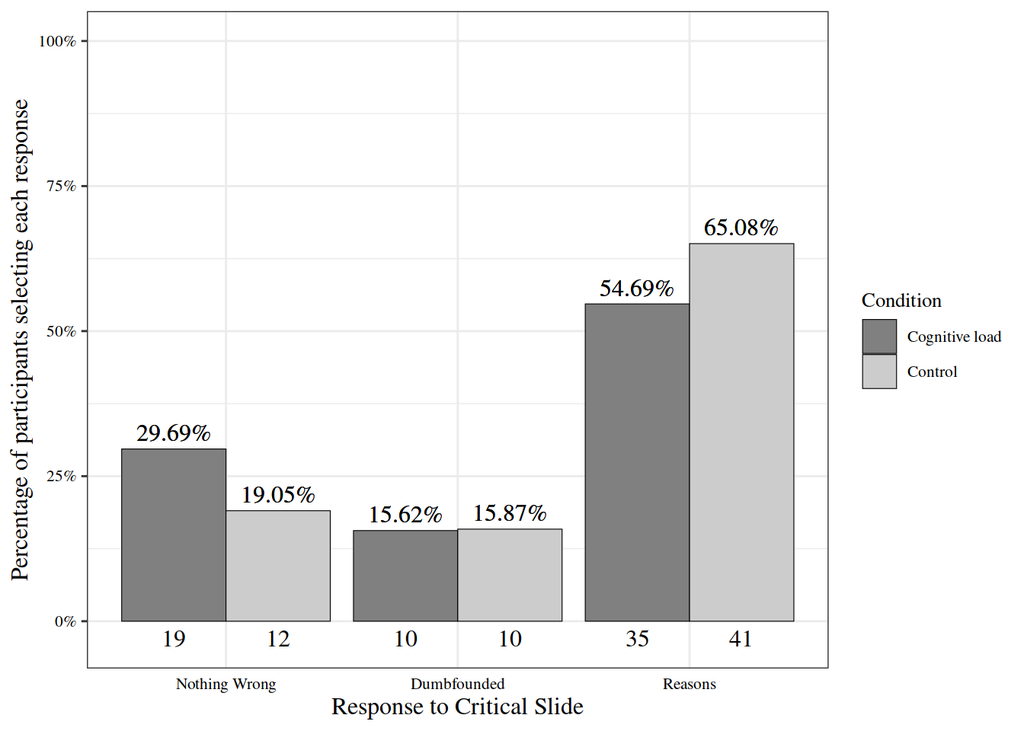

```r
ggplot(test, aes(x=InCS, y=perc, fill=factor(condition,labels=c("Cognitive load","Control")))) +
  scale_y_continuous(limits = c(-.03,1),
                     labels = percent_format()
  )+
  geom_col(position = "dodge",
           color="black",
           size=.2
  )+
  geom_text(family = "Times", size=4.2,
            aes( label = scales::percent(test$perc),
                 y= perc ),
            stat= "identity",
            vjust = -.5,
            position = position_dodge(.9),
            fontface='plain'
            )+
  geom_text(family = "Times", size=4.2,
            aes(label = format(Freq),
                y= -3*(..count../100)/(..count..)),
            stat= "count",
            position = position_dodge(0.9),
            #vjust = -.05,
            fontface='plain'
            ) +
  xlab("Response to Critical Slide") +
  ylab("Percentage of participants selecting each response")+
  scale_x_discrete(labels=c("Nothing Wrong", "Dumbfounded","Reasons")) +
  scale_fill_grey(start = .5, end = .8) +
  labs(fill="Condition") +

  geom_text(family = "Times", size=4.2,
            aes( label = scales::percent(test$perc),
                 y= test$perc ),
            stat= "identity",
            vjust = -.5,
            position = position_dodge(.9),
            fontface='plain'
            )+
  #theme_apa() +
  theme_bw() +
  theme(plot.title=element_text(family="Times",
                                size=12
                                ),
        legend.text=element_text(family="Times",
                                 size=8
                                 ),
          legend.title=element_text(family="Times",
                                    size=10
                                    ),
          axis.text=element_text(family="Times",
                                 colour = "black",
                                 size=8
                                 ),
          axis.ticks.x = element_blank(),
          axis.title=element_text(family="Times",
                                  size=12
                                  ),
          strip.text=element_text(family = "Times",
                                  size = 12
                                  ),
          strip.background = element_rect(fill = "white"),
          legend.position="right")
```

```r
#rm(a,b,c)
#
# g <- ggplot(df3, aes(x=InCS, fill=factor(condition,labels=c("Cognitive load","Control"))))
# g <- g + geom_bar(aes(y=..count..), position = position_dodge(), color="black")
# g <- g + xlab("Response to critical slide")
# #g <- g + ggtitle("Dumbfounding and Cognitive load")
# g <- g + scale_x_discrete(labels=c("nothing wrong", "no reason", "valid reason"))
# g <- g + scale_fill_grey(start = .5, end = .8)+ theme_bw()
# g <- g + labs(fill="Condition")
# #grid.gedit("GRID.text",gp=gpar(fontfamily="serif"))
# g <- g + geom_text(family = "Times", aes(label = format(..count..),y= ..count.. ), stat= "count", vjust = 1.6, position = position_dodge(0.9))
#
# g + theme(plot.title=element_text(family="Times", size=12), legend.text=element_text(family="Times", size=8), legend.title=element_text(family="Times", size=12), axis.text=element_text(family="Times", size=8), axis.title=element_text(family="Times", size=12))
# rm(g)
```

```r
sum(df3$InCS!="There is nothing wrong."&df3$Ju1_bin!="wrong")
```

```
## [1] 4
```

```r
t_j1 <- t.test(df3$InJu1 ~ df3$condition)
d_j1 <- cohensD(df3$InJu1 ~ df3$condition)

#t_j1 <- t.test(college$InJu1 ~ college$condition)
#t_paragraph(college$InJu1, college$condition, "initial judgement")
#t_paragraph(one$InJu1, one$condition, "initial judgement")
#t_paragraph(two$InJu1, two$condition, "initial judgement")
#t_paragraph(three$InJu1, three$condition, "initial judgement")

#
chisq.test(table(df3$InCS,df3$condition),correct = FALSE)
```

```
##
##  Pearson's Chi-squared test
##
## data:  table(df3$InCS, df3$condition)
## X-squared = 2.0466, df = 2, p-value = 0.3594
```

```r
chisq.test(table(df3$InCS,df3$condition),correct = TRUE)
```

```
##
##  Pearson's Chi-squared test
##
## data:  table(df3$InCS, df3$condition)
## X-squared = 2.0466, df = 2, p-value = 0.3594
```

```r
#c
c <- chisq.test(table(df3$InCS,df3$condition))
w <- sqrt(c[]$statistic/length(df3$gender))
pw <- pwr.chisq.test(w=w,N=length(df3$InCS),df=(3-1),sig.level = .05)
```

Ninety eight participants (77.17%) rated the behaviour of Julie and Mark as wrong initially. The mean initial rating of the behaviour was, *M* = 2.09, *SD* = 1.62. There was no difference in initial judgement depending on cognitive load, *t*(124.697157) = 0.5411897, *p* = .589; *d* = 0.1.

Participants who selected the admission of not having reasons on the critical slide were identified as dumbfounded. Twenty participants (15.75%) selected “It’s wrong but I can’t think of a reason.” Seventy six participants (59.84%) selected “It’s wrong and I can provide a valid reason”; and thirty one participants (24.41%) selected “There is nothing wrong.”

```r
head(df3)
```

[output not shown]

[output cut: 286 more lines]

```r
df3$DsCountry <- df3$v_296=="France"
df3$DsOccupation <- df3$v_306=="philosopher, mathematician and scientist"
df3$DsYear <- df3$v_307=="1637"
df3$Ds_correct_num <- df3$DsCountry+df3$DsOccupation+df3$DsYear
df3$Ds_correct_num
```

```
##   [1]  1  3  3  3  1  2  2  3  3  1  3  3  1  3  1  0  1  2  3  2  1  1  2  1  2
##  [26]  3  2  2  2  3  3  2  2  2  2  2  1  3 NA  3  2  3  3  2  1  2  3  0  1  3
##  [51]  3  1  0  3  2  2  1  1  1  1  3  3  0  3  2  2  1  1  3  3  1  3  3  2  1
##  [76]  3  2  2  1  1  0  1  1  0  2  1  1  2  2  3  2  1  3  2  3  2  3  0  3  2
## [101]  1  2  2  2  2  2  3  3  2  1  3  2  3  1  3  0  3  2  2  2  2  0  3  3  1
## [126]  1  2
```

```r
df3$DsEn <- df3$cog_load_mch_num>6
ds_engaged <- df3[which(df3$cog_Mch_num>6|df3$condition=="control"),]
tapply(df3$Ds_correct_num,df3$condition,descriptives)
```

```
## $cog_load
##       mean       sd min max len
## 1 1.968254 0.949843   0   3  64
##
## $control
##       mean        sd min max len
## 1 1.873016 0.9244364   0   3  63
```

```r
tapply(ds_engaged$Ds_correct_num,ds_engaged$condition,descriptives)
```

```
## $cog_load
##       mean       sd min max len
## 1 1.666667 1.527525   0   3   3
##
## $control
##       mean        sd min max len
## 1 1.873016 0.9244364   0   3  63
```

```r
summary(aov(Ds_correct_num~condition,data = ds_engaged))
```

```
##             Df Sum Sq Mean Sq F value Pr(>F)
## condition    1   0.12  0.1219   0.135  0.714
## Residuals   64  57.65  0.9008
```

```r
df4 <- df3[which(df3$condition=="cog_load"),]

variable.names(df3)
```

[output not shown]

[output cut: 55 more lines]

```r
aov1 <- summary(aov(Ds_correct_num~DsEn,data = df4))
summary(aov(Ds_correct_num~DsEn,data = df4))
```

```
##             Df Sum Sq Mean Sq F value Pr(>F)
## DsEn         1   0.21  0.2134   0.234  0.631
## Residuals   61  55.72  0.9135
## 1 observation deleted due to missingness
```

```r
tapply(df4$cog_load_mch_num,df4$DsEn,descriptives)
```

```
## $`FALSE`
##       mean       sd min max len
## 1 4.763158 1.172528   2   6  38
##
## $`TRUE`
##   mean        sd min max len
## 1 7.92 0.2768875   7   8  25
```

```r
table(df4$DsEn)
```

```
##
## FALSE  TRUE
##    38    25
```

```r
eta1 <- (aov1[[1]][["Sum Sq"]][1])/((aov1[[1]][["Sum Sq"]][1])+(aov1[[1]][["Sum Sq"]][2]))
pwr.anova.test(3,13,eta1)
```

```
##
##      Balanced one-way analysis of variance power calculation
##
##               k = 3
##               n = 13
##               f = 0.003814147
##       sig.level = 0.05
##           power = 0.05003915
##
## NOTE: n is number in each group
```

```r
cor.test(df4$Ds_correct_num,df4$cog_load_mch_num,type=pearson)
```

```
##
##  Pearson's product-moment correlation
##
## data:  df4$Ds_correct_num and df4$cog_load_mch_num
## t = 0.44282, df = 61, p-value = 0.6595
## alternative hypothesis: true correlation is not equal to 0
## 95 percent confidence interval:
##  -0.1938779  0.3001615
## sample estimates:
##        cor
## 0.05660624
```

```r
#qplot(df4$Ds_correct_num,df4$cog_load_mch_num,position_jitter(4))
#ggplot(df4,aes(Ds_correct_num,cog_load_mch_num))+geom_jitter(width=.25)

aov <- summary(aov(Ds_correct_num~condition,df3))

t_j1 <- t.test(df3$Ds_correct_num ~ df3$condition)
d_j1 <- cohensD(df3$Ds_correct_num ~ df3$condition)

table(df3$condition)
```

```
##
## cog_load  control
##       64       63
```

```r
eta <- (aov[[1]][["Sum Sq"]][1])/((aov[[1]][["Sum Sq"]][1])+(aov[[1]][["Sum Sq"]][2]))
pwr.anova.test(2,127,eta)
```

```
##
##      Balanced one-way analysis of variance power calculation
##
##               k = 2
##               n = 127
##               f = 0.002616279
##       sig.level = 0.05
##           power = 0.05019767
##
## NOTE: n is number in each group
```

```r
df3$Ds_time_log <- log10(df3$Ds_time)
df3$Ds_time_sq <- df3$Ds_time*df3$Ds_time

aov1 <- summary(aov(Ds_time_sq~condition,df3))

t_j2 <- t.test(df3$Ds_time_sq ~ df3$condition)
d_j2 <- cohensD(df3$Ds_time_sq ~ df3$condition)

eta1 <- (aov1[[1]][["Sum Sq"]][1])/((aov1[[1]][["Sum Sq"]][1])+(aov1[[1]][["Sum Sq"]][2]))
pwr.anova.test(2,127,eta1)
```

```
##
##      Balanced one-way analysis of variance power calculation
##
##               k = 2
##               n = 127
##               f = 0.02013423
##       sig.level = 0.05
##           power = 0.06178641
##
## NOTE: n is number in each group
```

```r
tapply(df3$Ds_time_sq,df3$condition,descriptives)
```

```
## $cog_load
##       mean    sd min    max len
## 1 12645.12 49474  16 334084  64
##
## $control
##       mean       sd min   max len
## 1 2639.476 2776.779   4 11449  63
```

```r
tapply(df3$Ds_time,df3$condition,descriptives)
```

```
## $cog_load
##       mean       sd min max len
## 1 62.28125 94.36798   4 578  64
##
## $control
##       mean       sd min max len
## 1 45.38095 24.27758   2 107  63
```

```r
tapply(df3$Ds_time_log,df3$condition,descriptives)
```

```
## $cog_load
##       mean        sd     min      max len
## 1 1.579255 0.4069816 0.60206 2.761928  64
##
## $control
##       mean        sd     min      max len
## 1 1.582269 0.2920024 0.30103 2.029384  63
```

```r
#aov <- summary(aov(Ds_correct_num~condition,df3))
#aov1 <- summary(aov(Ds_time_sq~condition,df3))
```

The responses to the manipulation check questions were investigated. There was no difference in the number of correct answers to these questions between the cognitive load group and the control group *t*(123.9089611) = 0.5703241, *p* = .569; *d* = 0.1. There was also no difference in time taken to read the vignette between the groups *t*(63.4032022) = 1.6153418, *p* = .111; *d* = 0.28.

```r
c <- chisq.test(table(df3$InCS,df3$condition))
rownames(rbind(round(c$observed),c$expected,c$stdres))
```

```
## [1] "There is nothing wrong."
## [2] "It's wrong but I can't think of a reason."
## [3] "It's wrong and I can provide a valid reason."
## [4] "There is nothing wrong."
## [5] "It's wrong but I can't think of a reason."
## [6] "It's wrong and I can provide a valid reason."
## [7] "There is nothing wrong."
## [8] "It's wrong but I can't think of a reason."
## [9] "It's wrong and I can provide a valid reason."
```

```r
ps <- function(y){
  if(as.numeric(sqrt( y*y) ) >3.3) print(paste0(y,"**"), quote = FALSE)
  else if(as.numeric(sqrt( y*y) ) >1.96) print(paste0(y,"*"), quote = FALSE)
  else print(y)}


x <- c$stdres
x <- round(x, digits = 2)

lapply(x, ps)
```

```
## [1] 1.4
## [1] -0.04
## [1] -1.19
## [1] -1.4
## [1] 0.04
## [1] 1.19
```

```
## [[1]]
## [1] 1.4
##
## [[2]]
## [1] -0.04
##
## [[3]]
## [1] -1.19
##
## [[4]]
## [1] -1.4
##
## [[5]]
## [1] 0.04
##
## [[6]]
## [1] 1.19
```

```r
#c$stdres <- round(c$stdres,digits=3)
#c$stdres <- ps(c$stdres)

ps(x[1])
```

```
## [1] 1.4
```

```r
ps(x[2])
```

```
## [1] -0.04
```

```r
ps(x[3])
```

```
## [1] -1.19
```

```r
x <- `colnames<-`(
  cbind.data.frame(c(ps(x[1]),ps(x[2]),ps(x[3])),
                   c(ps(x[4]),ps(x[5]),ps(x[6]))),
  c("cog_load","control")
)
```

```
## [1] 1.4
## [1] -0.04
## [1] -1.19
## [1] -1.4
## [1] 0.04
## [1] 1.19
```

```r
rownames(x) <- row.names(c$observed)

y <- rbind(round(c$observed), round(c$expected, digits = 2))

c(c$stdres[1])
```

```
## [1] 1.395669
```

```r
res <- cbind(c("Observed count","","","Expected count","","","Standardised residuals","",""),
      c("Nothing Wrong","Dumbfounded","Reasons",
        "Nothing Wrong","Dumbfounded","Reasons",
        "Nothing Wrong","Dumbfounded","Reasons"),
      rbind(y,x)

      )

row.names(res) <- NULL
colnames(res) <- c("","","Cognitive Load","Control")
```

```r
apa_table(
   res
   , align = c("l", "l", "c", "c", "c")
   , caption = "Study 4 – Observed counts, expected counts, and standardised residuals for each response to the critical slide depending on cognitive load"
   #, added_stub_head = "Response to critical slide"
   #, col_spanners = makespanners()
   , note = "* = sig. at \\emph{p} < .05; ** = sig. at \\emph{p} < .001"
   , escape = FALSE

)
```

Table 4:

*Study 4 – Observed counts, expected counts, and standardised residuals for each response to the critical slide depending on cognitive load*

|  |  | Cognitive Load | Control |
| --- | --- | --- | --- |
| Observed count | Nothing Wrong | 19.00 | 12.00 |
|  | Dumbfounded | 10.00 | 10.00 |
|  | Reasons | 35.00 | 41.00 |
| Expected count | Nothing Wrong | 15.62 | 15.38 |
|  | Dumbfounded | 10.08 | 9.92 |
|  | Reasons | 38.30 | 37.70 |
| Standardised residuals | Nothing Wrong | 1.40 | -1.40 |
|  | Dumbfounded | -0.04 | 0.04 |
|  | Reasons | -1.19 | 1.19 |

*Note.* * = sig. at < .05; ** = sig. at < .001

### Cognitive load and dumbfounded responding

A chi-squared test for independence revealed no significant association between experimental condition and response to the critical slide, $\chi$<sup>2</sup>(2, *N* = 127) = 2.047, *p* = .359, *V* = 0.1269442, the observed power was 0.2299931. The responses to the critical slide for the experimental group (*N* = 64) and the control group (*N* = 63) are displayed in Figure 6. The observed counts, expected counts and standardised residuals are displayed in Table 4.

```r
# df3 <- zero_one_two_three
# df3 <- zero_one_two_three_five
# df3 <- three
#df3 <- zero_one_two_three_five
df3$InCS <- relevel(df3$InCS, ref = 2)

df3a <- mlogit.data(df3, choice = "InCS", shape = "wide")
InCSModel<-mlogit(InCS ~ 1 | NFC, data = df3a, reflevel = "It's wrong and I can provide a valid reason.")

summary_InCS_model <- summary(InCSModel)
summary_InCS_model$lratio$parameter
```

```
## df
##  2
```

```r
summary_InCS_model$lratio$statistic
```

```
## 'log Lik.' 1.502547 (df=4)
```

```r
summary_InCS_model$lratio$p.value
```

```
## 'log Lik.' 0.4717655 (df=4)
```

```r
InCSModel$coefficients[3]
```

```
## NFC:It's wrong but I can't think of a reason.
##                                    -0.1576009
```

```r
InCSModel$coefficients[4]
```

```
## NFC:There is nothing wrong.
##                  0.05311469
```

```r
cox <- PseudoR2(multinom(InCS~NFC,df3), "all")
cox[3]
```

```
##  CoxSnell
## 0.0120442
```

```r
cox[4]
```

```
## Nagelkerke
## 0.01414873
```

```r
#PseudoR2(x, "all")
#summary_InCS_model


wald1 <-
  summary_InCS_model$CoefTable[3]^2 /
  summary_InCS_model$CoefTable[7]^2

wald2 <-
  summary_InCS_model$CoefTable[4]^2 /
  summary_InCS_model$CoefTable[8]^2


summary_InCS_model
```

```
##
## Call:
## mlogit(formula = InCS ~ 1 | NFC, data = df3a, reflevel = "It's wrong and I can provide a valid reason.",
##     method = "nr")
##
## Frequencies of alternatives:choice
## It's wrong and I can provide a valid reason.
##                                      0.58871
##    It's wrong but I can't think of a reason.
##                                      0.16129
##                      There is nothing wrong.
##                                      0.25000
##
## nr method
## 4 iterations, 0h:0m:0s
## g'(-H)^-1g = 0.00269
## successive function values within tolerance limits
##
## Coefficients :
##                                                        Estimate Std. Error
## (Intercept):It's wrong but I can't think of a reason. -1.218971   0.259984
## (Intercept):There is nothing wrong.                   -0.896615   0.239421
## NFC:It's wrong but I can't think of a reason.         -0.157601   0.153751
## NFC:There is nothing wrong.                            0.053115   0.135653
##                                                       z-value  Pr(>|z|)
## (Intercept):It's wrong but I can't think of a reason. -4.6886  2.75e-06 ***
## (Intercept):There is nothing wrong.                   -3.7449 0.0001804 ***
## NFC:It's wrong but I can't think of a reason.         -1.0250 0.3053441
## NFC:There is nothing wrong.                            0.3915 0.6953923
## ---
## Signif. codes:  0 '***' 0.001 '**' 0.01 '*' 0.05 '.' 0.1 ' ' 1
##
## Log-Likelihood: -117.39
## McFadden R^2:  0.006359
## Likelihood ratio test : chisq = 1.5025 (p.value = 0.47177)
```

```r
summary_InCS_model$coefficients[3]
```

```
## NFC:It's wrong but I can't think of a reason.
##                                    -0.1576009
```

```r
data.frame(exp(InCSModel$coefficients))
```

```
##                                                       exp.InCSModel.coefficients.
## (Intercept):It's wrong but I can't think of a reason.                   0.2955341
## (Intercept):There is nothing wrong.                                     0.4079481
## NFC:It's wrong but I can't think of a reason.                           0.8541906
## NFC:There is nothing wrong.                                             1.0545506
```

```r
exp(InCSModel$coefficients)[3]
```

```
## NFC:It's wrong but I can't think of a reason.
##                                     0.8541906
```

```r
a <- exp(confint(InCSModel))
c(a[3],a[7])
```

```
## [1] 0.6319486 1.1545901
```

```r
residuals(InCSModel)
```

[output not shown]

```r
fitted(InCSModel, outcome = F)
```

```
##     It's wrong and I can provide a valid reason.
## 1                                      0.5932728
## 2                                      0.6007958
## 3                                      0.5932728
## 4                                      0.5988551
## 5                                      0.5440195
## 6                                      0.5909950
## 7                                      0.6017452
## 8                                      0.5974967
## 9                                      0.5870341
## 10                                     0.6002613
## 11                                     0.5879715
## 12                                     0.6014690
## 13                                     0.5925453
## 14                                     0.5979790
```

[output cut: 235 more lines]

```r
c <- summary_InCS_model$lratio$statistic
w <- sqrt(c/length(df3$gender))
pw <- pwr.chisq.test(w=w,N=length(df3$InCS),df=(2),sig.level = .05)

pw$power
```

```
## [1] 0.1785767
```

```r
revised_PseudoR2s <- function(LogModel) {
  dev <- LogModel$deviance
  nullDev <- LogModel$null.deviance
  modelN <- length(LogModel$fitted.values)
  R.l <- 1 - dev / nullDev
  R.cs <- 1- exp ( -(nullDev - dev) / modelN)
  R.n <- R.cs / ( 1 - ( exp (-(nullDev / modelN))))

  all <- list(hosmer_and_lemeshow = as.numeric(R.l), mcfadden = NA, cox_and_snell = as.numeric(R.cs), nagelkerke = as.numeric(R.n))
  all
}

logits_rsquared <- glm(InCS~NFC,df3, family = binomial(link = "logit"))
cox <- revised_PseudoR2s(logits_rsquared)
```

### Need for Cognition

A multinomial logistic regression revealed no statistically significant association between Need for Cognition and response to the critical slide, $\chi$<sup>2</sup>(2, *N* = 127) = 1.5, *p* = .472, the observed power was 0.18.[^7]

```r
df3 <- df3[which(is.na(df3$NFC)==FALSE),]

x <- df3$NFC
y <- as.numeric(df3$InCS)

m1 <- multinom(y ~ x)
```

```r
# summary(m1)
newdata <- data.frame(x = seq(min(x), max(x), length.out = 100))
p1 <- predict(m1, newdata, type = "class")
p2 <- predict(m1, newdata, type = "probs")


logit_plot <- cbind.data.frame(newdata,p2)

logit_plot <- `colnames<-`(logit_plot, c("x","one_l","two_l","three_l"))
logit_plot <- melt(logit_plot, id="x")
```

## Study 4: Discussion

The significant relationship between cognitive load and response to the critical slide observed in previous studies was not observed in Study 4. However, the pattern of responses resembled the predicted relationship and resembled the pattern of responses observed in previous studies. In addition, the manipulation check did not reveal any differences between the control group and the experimental group, suggesting that the cognitive load manipulation was ineffective in Study 4. Studies 2, 3, and 4 were conducted using online samples recruited using Amazon’s MTurk (where experimental manipulations can be challenging e.g., Crump, McDonnell, & Gureckis, 2013; Goodman, Cryder, & Cheema, 2013). It is possible that, in addition to the manipulation being less effective than hoped, the online sample did not engage with the study as effectively as the participants in Study 1. We conducted a final study to assess if the effect found in Study 1 could be replicated.

# Study 5 - College Sample revisited

Given the inconclusive results across studies 1-4, Study 5 was to an attempt at a direct replication of Study 1, using a larger sample.

```r
rm(list = ls())

load("loaded_data/five.RData")
df3 <- study_5


df4 <- df3[which(df3$condition=="cog_load"),]
df5 <- df3[which(df3$condition=="control"),]
```

## Study 5: Method

### Participants and design

Study 5 was a between subjects design. The dependent variable was response to the critical slide. The independent variable was cognitive load with two levels: present and absent. Need for Cognition (Cacioppo & Petty, 1982; Petty, Cacioppo, & Kao, 1984) was included as a potential correlate and moderator variable.

A total sample of 204 participants (144 female, 59 male; *M*<sub>age</sub> = 20.56, min = 18, max = 48, *SD* = 3.86) took part. Participants in this sample were undergraduate students, postgraduate students, and alumni from Mary Immaculate College (MIC), and University of Limerick (UL). Participation was voluntary and participants were not reimbursed for their participation.

### Procedure and materials

Data were collected using an online questionnaire. Data collection took place in a designated computer laboratory in MIC. The experimenter remained in the laboratory for the duration of the study. Participants were first presented with an information sheet and consent form.

There were two sections of the online survey: the moral judgement task, and the Need for Cognition scale. The order of presentation of these was randomised. At the beginning of the moral judgement task, participants in the experimental condition were presented with an eight digit number/letter string and asked to memorise the sequence. After 30 seconds, the experiment progressed to the next slide. Participants had the option to click “ok” and progress to the next slide after 15 seconds.

Participants were then presented with the “Julie and Mark” (*Incest*) vignette (Haidt, Björklund, & Murphy, 2000). Participants rated how right or wrong the behaviour of Julie and Mark was, and were given an opportunity to provide reasons for their judgement. Following this, participants were presented with a series of counter-arguments, which refuted commonly used justifications for rating the behaviour as “wrong.” Dumbfounding was measured using the critical slide. Following the revised judgement participants were required to reproduce the number/letter string.

## Study 5: Results

```r
sum(df3$InCS!="There is nothing wrong."&df3$Ju1_bin!="wrong")
```

```
## [1] 3
```

```r
t_j1 <- t.test(df3$InJu1 ~ df3$condition)
d_j1 <- cohensD(df3$InJu1 ~ df3$condition)

#t_j1 <- t.test(college$InJu1 ~ college$condition)
#t_paragraph(college$InJu1, college$condition, "initial judgement")
#t_paragraph(one$InJu1, one$condition, "initial judgement")
#t_paragraph(two$InJu1, two$condition, "initial judgement")
#t_paragraph(three$InJu1, three$condition, "initial judgement")

chisq.test(table(df3$InCS,df3$condition),correct = FALSE)
```

```
##
##  Pearson's Chi-squared test
##
## data:  table(df3$InCS, df3$condition)
## X-squared = 3.0751, df = 2, p-value = 0.2149
```

```r
chisq.test(table(df3$InCS,df3$condition),correct = TRUE)
```

```
##
##  Pearson's Chi-squared test
##
## data:  table(df3$InCS, df3$condition)
## X-squared = 3.0751, df = 2, p-value = 0.2149
```

```r
#
```

A total of 165 participants (80.88%) rated the behaviour of Julie and Mark as wrong initially. The mean initial rating of the behaviour was, *M* = 2.01, *SD* = 1.82. There was no difference in initial judgement depending on cognitive load, *t*(191.1014256) = 1.0356595, *p* = .302; *d* = 0.15.

```r
#table(df3a$InCS,df3a$condition)
#chisq.test(table(df3$InCS,df3$condition))

table(df3$reason,df3$condition)
```

```
##
##         cog_load control
##   FALSE       43      37
##   TRUE        55      69
```

```r
chisq.test(table(df3$reason,df3$condition))
```

```
##
##  Pearson's Chi-squared test with Yates' continuity correction
##
## data:  table(df3$reason, df3$condition)
## X-squared = 1.3638, df = 1, p-value = 0.2429
```

```r
table(df3$InCS, df3$cog_number_right)
```

```
##
##                                                 0  2  3  4  5  6  7  8
##   There is nothing wrong.                      18  0  0  3  3  3  6  7
##   It's wrong but I can't think of a reason.    20  0  1  3  6  1  3 11
##   It's wrong and I can provide a valid reason. 68  2  2  5  2  8  8 24
```

```r
df4a <- df4[which(df4$cog_number_right>2),]
df3a <- rbind(df4a,df5)

table(df3$InCS,df3$condition)
```

```
##
##                                                cog_load control
##   There is nothing wrong.                            22      18
##   It's wrong but I can't think of a reason.          25      20
##   It's wrong and I can provide a valid reason.       51      68
```

```r
chisq.test(table(df3$InCS,df3$condition))
```

```
##
##  Pearson's Chi-squared test
##
## data:  table(df3$InCS, df3$condition)
## X-squared = 3.0751, df = 2, p-value = 0.2149
```

```r
## what's going on???

df3[which(df3$InCS!="It's wrong and I can provide a valid reason."&df3$condition=="cog_load"),]
```

[output not shown]

[output cut: 2001 more lines]

```r
df3[which(df3$participant=="3"),]
```

[output not shown]

[output cut: 25 more lines]

[output not shown]

```r
df3[which(df3$participant=="6"),]
```

[output not shown]

[output cut: 27 more lines]

[output not shown]

```r
df3[which(df3$participant=="12"),]
```

[output not shown]

[output cut: 23 more lines]

[output not shown]

```r
df3[which(df3$participant=="14"),]
```

[output not shown]

[output cut: 25 more lines]

[output not shown]

```r
# df7 <- rbind(df7,
#              df3[which(df3$participant=="3"),],
#              df3[which(df3$participant=="6"),],
#              df3[which(df3$participant=="12"),],
#              df3[which(df3$participant=="14"),])
#
# df7 <- rbind(df7,
#              df3[which(df3$participant=="14"),])

# table(df7$InCS,df7$condition)
# chisq.test(table(df7$InCS,df7$condition))
#
# df8 <- rbind(df3,df3)
# table(df8$InCS,df8$condition)
# chisq.test(table(df8$InCS,df8$condition))



test <- as.data.frame.matrix((table(df3$InCS,df3$condition)))
`rownames<-`(test, c("nothing wrong","no reason","reasons"))
```

```
##               cog_load control
## nothing wrong       22      18
## no reason           25      20
## reasons             51      68
```

```r
test <- as.matrix((test))
test1 <- cbind(test[,1],test[,2])
test2 <- `colnames<-`(test1, c("cognitive load","control"))

tb_count_perc <- function(x){
  tc <- table(x$InCS,x$condition)
  cbind(tc[,1],paste0(round(tc[,1]/sum(x$condition=="cog_load")*100),"%"),
        tc[,2],paste0(round(tc[,2]/sum(x$condition=="control")*100),"%"))
  }

  tb_count_perc_eng <- function(x){
  tc <- table(x$InCS,x$engaged)
  cbind(tc[,1],paste0(round(tc[,1]/sum(x$engaged=="engaged")*100),"%"),
        tc[,2],paste0(round(tc[,2]/sum(x$engaged=="not engaged")*100),"%"))
  }

  test <- tb_count_perc(df3)
  colnames(test) <- c("N","percent","N","percent")

  makespanners <- function(){
  cog_load <- c(2,3)
  control <- c(4,5)
  spans <- list(cog_load,control)
  names(spans) <- c("Cognitive Load","Control")
  spans
}

tb_count_perc(df3)
```

```
##                                              [,1] [,2]  [,3] [,4]
## There is nothing wrong.                      "22" "22%" "18" "17%"
## It's wrong but I can't think of a reason.    "25" "26%" "20" "19%"
## It's wrong and I can provide a valid reason. "51" "52%" "68" "64%"
```

```r
#tb_count_perc(df3a)
```

```r
y <- table(df3$condition,df3$InCS)
y <- as.data.frame(y)
colnames(y) <- c("condition","InCS","Freq")

z <- as.data.frame(table(df3$condition,df3$InCS)/length(df3$gender)*2)
perc <- z$Freq
test <- cbind(y,perc)
test$condition
```

```
## [1] cog_load control  cog_load control  cog_load control
## Levels: cog_load control
```

```r
test
```

```
##   condition                                         InCS Freq      perc
## 1  cog_load                      There is nothing wrong.   22 0.2156863
## 2   control                      There is nothing wrong.   18 0.1764706
## 3  cog_load    It's wrong but I can't think of a reason.   25 0.2450980
## 4   control    It's wrong but I can't think of a reason.   20 0.1960784
## 5  cog_load It's wrong and I can provide a valid reason.   51 0.5000000
## 6   control It's wrong and I can provide a valid reason.   68 0.6666667
```

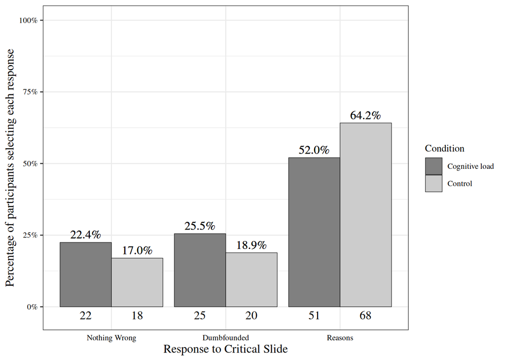

Figure 7: Study 5: Responses to critical slide and for the experimental group (*N* = 98) and the control group (*N* = 106)

```r
#y <- table(df3$condition,df3$Dumb_incl_string)
#y <- as.data.frame(y)
#colnames(y) <- c("condition","InCS","Freq")

# z <- as.data.frame(table(df3$condition,df3$Dumb_incl_string)/length(df3$gender)*2)
# perc <- z$Freq
# test <- cbind(y,perc)
# test$condition
# test


ab_graph <- function(){
  a <- df3[which(df3$condition==levels(as.factor(df3$condition))[1]),]
  b <- df3[which(df3$condition==levels(as.factor(df3$condition))[2]),]
  a#levels(as.factor(df3$condition))[1]

  ay <- as.data.frame(table(a$InCS,as.character(a$condition)))
  by <- as.data.frame(table(b$InCS,as.character(b$condition)))

  aperc <- ay$Freq/length(a$gender)
  ay <- cbind(ay,aperc)
  colnames(ay) <- c("InCS","condition","Freq","perc")

  bperc <- by$Freq/length(b$gender)
  by <- cbind(by,bperc)
  colnames(by) <- c("InCS","condition","Freq","perc")

  c <- rbind(ay,by)

  c
}

test <- ab_graph()



rm(x,y)
ggplot(test, aes(x=InCS, y=perc, fill=factor(condition,labels=c("Cognitive load","Control")))) +
  scale_y_continuous(limits = c(-.03,1),
                     labels = percent_format()
  )+
  geom_col(position = "dodge",
           color="black",
           size=.2
  )+
  geom_text(family = "Times", size=4.2,
            aes( label = scales::percent(test$perc),
                 y= perc ),
            stat= "identity",
            vjust = -.5,
            position = position_dodge(.9),
            fontface='plain'
            )+
  geom_text(family = "Times", size=4.2,
            aes(label = format(Freq),
                y= -3*(..count../100)/(..count..)),
            stat= "count",
            position = position_dodge(0.9),
            #vjust = -.05,
            fontface='plain'
            ) +
  xlab("Response to Critical Slide") +
  ylab("Percentage of participants selecting each response")+
  scale_x_discrete(labels=c("Nothing Wrong", "Dumbfounded","Reasons")) +
  scale_fill_grey(start = .5, end = .8) +
  labs(fill="Condition") +

  geom_text(family = "Times", size=4.2,
            aes( label = scales::percent(test$perc),
                 y= test$perc ),
            stat= "identity",
            vjust = -.5,
            position = position_dodge(.9),
            fontface='plain'
            )+
  #theme_apa() +
  theme_bw() +
  theme(plot.title=element_text(family="Times",
                                size=12
                                ),
        legend.text=element_text(family="Times",
                                 size=8
                                 ),
          legend.title=element_text(family="Times",
                                    size=10
                                    ),
          axis.text=element_text(family="Times",
                                 colour = "black",
                                 size=8
                                 ),
          axis.ticks.x = element_blank(),
          axis.title=element_text(family="Times",
                                  size=12
                                  ),
          strip.text=element_text(family = "Times",
                                  size = 12
                                  ),
          strip.background = element_rect(fill = "white"),
          legend.position="right")
```

```r
c <- chisq.test(table(df3$InCS,df3$condition))
rownames(rbind(c$observed,c$expected,c$stdres))
```

```
## [1] "There is nothing wrong."
## [2] "It's wrong but I can't think of a reason."
## [3] "It's wrong and I can provide a valid reason."
## [4] "There is nothing wrong."
## [5] "It's wrong but I can't think of a reason."
## [6] "It's wrong and I can provide a valid reason."
## [7] "There is nothing wrong."
## [8] "It's wrong but I can't think of a reason."
## [9] "It's wrong and I can provide a valid reason."
```

```r
ps <- function(y){
  if(as.numeric(sqrt( y*y) ) >3.3) print(paste0(y,"**"), quote = FALSE)
  else if(as.numeric(sqrt( y*y) ) >1.96) print(paste0(y,"*"), quote = FALSE)
  else print(y)}


x <- c$stdres
x <- round(x, digits = 2)

lapply(x, ps)
```

```
## [1] 0.98
## [1] 1.14
## [1] -1.75
## [1] -0.98
## [1] -1.14
## [1] 1.75
```

```
## [[1]]
## [1] 0.98
##
## [[2]]
## [1] 1.14
##
## [[3]]
## [1] -1.75
##
## [[4]]
## [1] -0.98
##
## [[5]]
## [1] -1.14
##
## [[6]]
## [1] 1.75
```

```r
#c$stdres <- round(c$stdres,digits=3)
#c$stdres <- ps(c$stdres)

ps(x[1])
```

```
## [1] 0.98
```

```r
ps(x[2])
```

```
## [1] 1.14
```

```r
ps(x[3])
```

```
## [1] -1.75
```

```r
x <- `colnames<-`(
  cbind.data.frame(c(ps(x[1]),ps(x[2]),ps(x[3])),
                   c(ps(x[4]),ps(x[5]),ps(x[6]))),
  c("cog_load","control")
)
```

```
## [1] 0.98
## [1] 1.14
## [1] -1.75
## [1] -0.98
## [1] -1.14
## [1] 1.75
```

```r
rownames(x) <- row.names(c$observed)

y <- rbind(round(c$observed), round(c$expected, digits = 2))

c(c$stdres[1])
```

```
## [1] 0.9827556
```

```r
res <- cbind(c("Observed count","","","Expected count","","","Standardised residuals","",""),
      c("Nothing Wrong","Dumbfounded","Reasons",
        "Nothing Wrong","Dumbfounded","Reasons",
        "Nothing Wrong","Dumbfounded","Reasons"),
      rbind(y,x)

      )

row.names(res) <- NULL
colnames(res) <- c("","","Cognitive Load","Control")
```

```r
apa_table(
   res
   , align = c("l", "l", "c", "c", "c")
   , caption = "Study 5 – Observed counts, expected counts, and standardised residuals for each response to the critical slide depending on cognitive load"
   #, added_stub_head = "Response to critical slide"
   #, col_spanners = makespanners()
   , note = "* = sig. at \\emph{p} < .05; ** = sig. at \\emph{p} < .001"
   , escape = FALSE

)
```

Table 5:

*Study 5 – Observed counts, expected counts, and standardised residuals for each response to the critical slide depending on cognitive load*

|  |  | Cognitive Load | Control |
| --- | --- | --- | --- |
| Observed count | Nothing Wrong | 22.00 | 18.00 |
|  | Dumbfounded | 25.00 | 20.00 |
|  | Reasons | 51.00 | 68.00 |
| Expected count | Nothing Wrong | 19.22 | 20.78 |
|  | Dumbfounded | 21.62 | 23.38 |
|  | Reasons | 57.17 | 61.83 |
| Standardised residuals | Nothing Wrong | 0.98 | -0.98 |
|  | Dumbfounded | 1.14 | -1.14 |
|  | Reasons | -1.75 | 1.75 |

*Note.* * = sig. at < .05; ** = sig. at < .001

Participants who selected the admission of not having reasons on the critical slide were identified as dumbfounded. Forty five participants (22.06%) selected “It’s wrong but I can’t think of a reason.” one hundred Nineteen participants (58.33%) selected “It’s wrong and I can provide a valid reason”; and forty participants (19.61%) selected “There is nothing wrong.”

### Cognitive load manipulation check

Initial check of responses to the memory task revealed that 42 participants (42.86%) successfully remembered the sequence of numbers and letters. Responses to the manipulation check question revealed that 22 participants (22.45%) found the memory task easy. Of these, 20 participants both found the task easy and got the answer right. All participants correctly remembered at least two digits suggesting engagement with the manipulation.

The cognitive load manipulation took place before the presenting of the vignette describing the behaviour to be judged. This allowed for the possibility that participants under cognitive load may not have engaged fully with the vignette when compared to the control group. An independent samples t-test revealed no significant difference in initial rating in the cognitive load group, (*M* = 2.15, *SD* = 1.97), and the control group, (*M* = 2.05, *SD* = 1.66), *t*(191.1) = 1.036 , *p* = 0.302; *d* = 0.15. An independent samples t-test revealed no significant difference in initial confidence in the cognitive load group, (*M* = 5.51, *SD* = 1.55), and the control group, (*M* = 5.83, *SD* = 1.49), *t*(199.05) = -1.499 , *p* = 0.136; *d* = 0.21. In view of this, it was concluded that both groups engaged equally with the task.

```r
c <- chisq.test(table(df3$InCS,df3$condition))
w <- sqrt(c[]$statistic/length(df3$gender))
pw <- pwr.chisq.test(w=w,N=length(df3$InCS),df=(3-1),sig.level = .05)
```

### Cognitive load and dumbfounded responding

A chi-squared test for independence revealed no significant association between experimental condition and response to the critical slide, $\chi$<sup>2</sup>(2, *N* = 204) = 3.075, *p* = .215, *V* = 0.1227769, the observed power was 0.3287051. The predicted relationship between cognitive load and dumbfounded responding was not observed in Study 5. The responses to the critical slide for the experimental group (*N* = 98) and the control group (*N* = 106) are displayed in Figure 7. The observed counts, expected counts and standardised residuals are displayed in Table 5.

```r
# df3 <- zero_one_two_three
# df3 <- zero_one_two_three_five
# df3 <- three
# df3 <- zero_one_two_three_five
# df3 <- four_and_five
df3$InCS <- relevel(df3$InCS, ref = 2)

df3a <- mlogit.data(df3, choice = "InCS", shape = "wide")
InCSModel<-mlogit(InCS ~ 1 | NFC, data = df3a, reflevel = "It's wrong and I can provide a valid reason.")

summary_InCS_model <- summary(InCSModel)
summary_InCS_model$lratio$parameter
```

```
## df
##  2
```

```r
summary_InCS_model$lratio$statistic
```

```
## 'log Lik.' 5.827285 (df=4)
```

```r
summary_InCS_model$lratio$p.value
```

```
## 'log Lik.' 0.05427766 (df=4)
```

```r
InCSModel$coefficients[3]
```

```
## NFC:It's wrong but I can't think of a reason.
##                                    -0.4326575
```

```r
InCSModel$coefficients[4]
```

```
## NFC:There is nothing wrong.
##                 -0.07907443
```

```r
cox <- PseudoR2(multinom(InCS~NFC,df3), "all")
cox[3]
```

```
##   CoxSnell
## 0.02816101
```

```r
cox[4]
```

```
## Nagelkerke
## 0.03291709
```

```r
#PseudoR2(x, "all")
#summary_InCS_model


wald1 <-
  summary_InCS_model$CoefTable[3]^2 /
  summary_InCS_model$CoefTable[7]^2

wald2 <-
  summary_InCS_model$CoefTable[4]^2 /
  summary_InCS_model$CoefTable[8]^2


summary_InCS_model
```

```
##
## Call:
## mlogit(formula = InCS ~ 1 | NFC, data = df3a, reflevel = "It's wrong and I can provide a valid reason.",
##     method = "nr")
##
## Frequencies of alternatives:choice
## It's wrong and I can provide a valid reason.
##                                      0.58333
##    It's wrong but I can't think of a reason.
##                                      0.22059
##                      There is nothing wrong.
##                                      0.19608
##
## nr method
## 4 iterations, 0h:0m:0s
## g'(-H)^-1g = 0.00121
## successive function values within tolerance limits
##
## Coefficients :
##                                                        Estimate Std. Error
## (Intercept):It's wrong but I can't think of a reason. -0.840276   0.182604
## (Intercept):There is nothing wrong.                   -1.052584   0.201501
## NFC:It's wrong but I can't think of a reason.         -0.432658   0.184810
## NFC:There is nothing wrong.                           -0.079074   0.185244
##                                                       z-value  Pr(>|z|)
## (Intercept):It's wrong but I can't think of a reason. -4.6016 4.192e-06 ***
## (Intercept):There is nothing wrong.                   -5.2237 1.754e-07 ***
## NFC:It's wrong but I can't think of a reason.         -2.3411   0.01923 *
## NFC:There is nothing wrong.                           -0.4269   0.66948
## ---
## Signif. codes:  0 '***' 0.001 '**' 0.01 '*' 0.05 '.' 0.1 ' ' 1
##
## Log-Likelihood: -194.41
## McFadden R^2:  0.014766
## Likelihood ratio test : chisq = 5.8273 (p.value = 0.054278)
```

```r
summary_InCS_model$coefficients[3]
```

```
## NFC:It's wrong but I can't think of a reason.
##                                    -0.4326575
```

```r
data.frame(exp(InCSModel$coefficients))
```

```
##                                                       exp.InCSModel.coefficients.
## (Intercept):It's wrong but I can't think of a reason.                   0.4315913
## (Intercept):There is nothing wrong.                                     0.3490346
## NFC:It's wrong but I can't think of a reason.                           0.6487826
## NFC:There is nothing wrong.                                             0.9239712
```

```r
exp(InCSModel$coefficients)[3]
```

```
## NFC:It's wrong but I can't think of a reason.
##                                     0.6487826
```

```r
a <- exp(confint(InCSModel))
c(a[3],a[7])
```

```
## [1] 0.4516362 0.9319866
```

```r
residuals(InCSModel)
```

[output not shown]

```r
fitted(InCSModel, outcome = F)
```

[output not shown]

[output cut: 395 more lines]

```r
c <- summary_InCS_model$lratio$statistic
w <- sqrt(c/length(df3$gender))
pw <- pwr.chisq.test(w=w,N=length(df3$InCS),df=(2),sig.level = .05)

pw$power
```

```
## [1] 0.5707804
```

```r
revised_PseudoR2s <- function(LogModel) {
  dev <- LogModel$deviance
  nullDev <- LogModel$null.deviance
  modelN <- length(LogModel$fitted.values)
  R.l <- 1 - dev / nullDev
  R.cs <- 1- exp ( -(nullDev - dev) / modelN)
  R.n <- R.cs / ( 1 - ( exp (-(nullDev / modelN))))

  all <- list(hosmer_and_lemeshow = as.numeric(R.l), mcfadden = NA, cox_and_snell = as.numeric(R.cs), nagelkerke = as.numeric(R.n))
  all
}

logits_rsquared <- glm(InCS~NFC,df3, family = binomial(link = "logit"))
cox <- revised_PseudoR2s(logits_rsquared)
#
# round(cox[3]*100, digits=2)
# round(cox$cox_and_snell*100, digits=2)
# cox$cox_and_snell*100
#
# round(cox[4]*100, digits=2)
# round(cox$nagelkerke*100, digits=2)
# cox$nagelkerke*100
```

### Need for Cognition

```r
df3 <- df3[which(is.na(df3$NFC)==FALSE),]

x <- df3$NFC
y <- as.numeric(df3$InCS)

m1 <- multinom(y ~ x)
```

```r
# summary(m1)
newdata <- data.frame(x = seq(min(x), max(x), length.out = 100))
p1 <- predict(m1, newdata, type = "class")
p2 <- predict(m1, newdata, type = "probs")


logit_plot <- cbind.data.frame(newdata,p2)

logit_plot <- `colnames<-`(logit_plot, c("x","one_l","two_l","three_l"))
logit_plot <- melt(logit_plot, id="x")
```

## Study 5: Discussion

Study 5 failed to demonstrate the predicted relationship between cognitive load and response to the critical slide. This provides some evidence to suggest that the failure of Study 4 to demonstrate this effect is likely not due to the use of an online sample. As with Study 4, the pattern of responses in Study 5 resembled the predicted relationship. The overall relationship between Need for Cognition and response to the critical slide was non-significant, however there were trends in the predicted direction. As noted previously, the studies reported here lack the statistical power to detect anything other than a large effect. As such, in the next section we aggregate the data from all the studies and conduct a combined analysis. We also conduct mini-meta-analyses for the primary research question.

# Study 6: Video Task

[video not shown]

Hypothesised relationship between responses in the dumbfounding paradigm and level of deliberation

```r
rm(list = ls())

load("loaded_data/six.RData")
df3 <- study_6
df3$InCS
```

```
##  [1] "There is nothing wrong."
##  [2] "It's wrong and I can provide a valid reason."
##  [3] "It's wrong but I can't think of a reason."
##  [4] "It's wrong and I can provide a valid reason."
##  [5] "There is nothing wrong."
##  [6] "There is nothing wrong."
##  [7] "It's wrong but I can't think of a reason."
##  [8] "It's wrong but I can't think of a reason."
##  [9] "It's wrong and I can provide a valid reason."
## [10] "There is nothing wrong."
## [11] "It's wrong and I can provide a valid reason."
## [12] "It's wrong but I can't think of a reason."
## [13] "It's wrong but I can't think of a reason."
## [14] "It's wrong but I can't think of a reason."
## [15] "It's wrong but I can't think of a reason."
## [16] NA
## [17] "There is nothing wrong."
## [18] "It's wrong and I can provide a valid reason."
## [19] "It's wrong and I can provide a valid reason."
## [20] "There is nothing wrong."
## [21] "It's wrong and I can provide a valid reason."
## [22] "There is nothing wrong."
```

```r
df3 <- df3[which(is.na(df3$InCS)==FALSE),]

df4 <- df3[which(df3$condition=="cog_load"),]
df5 <- df3[which(df3$condition=="control"),]
#df3$InCS <- df3$CS
```

```r
sum(df3$CS!="There is nothing wrong."&df3$Ju1_bin!="wrong")
```

```
## [1] 4
```

```r
t_j1 <- t.test(df3$InJu1 ~ df3$condition)
d_j1 <- cohensD(df3$InJu1 ~ df3$condition)

#t_j1 <- t.test(college$InJu1 ~ college$condition)
#t_paragraph(college$InJu1, college$condition, "initial judgement")
#t_paragraph(one$InJu1, one$condition, "initial judgement")
#t_paragraph(two$InJu1, two$condition, "initial judgement")
#t_paragraph(three$InJu1, three$condition, "initial judgement")

chisq.test(table(df3$InCS,df3$condition),correct = FALSE)
```

```
##
##  Pearson's Chi-squared test
##
## data:  table(df3$InCS, df3$condition)
## X-squared = 4.9636, df = 2, p-value = 0.08359
```

```r
chisq.test(table(df3$InCS,df3$condition),correct = TRUE)
```

```
##
##  Pearson's Chi-squared test
##
## data:  table(df3$InCS, df3$condition)
## X-squared = 4.9636, df = 2, p-value = 0.08359
```

```r
#
```

A total of 17 participants (80.95%) rated the behaviour of Julie and Mark as wrong initially. The mean initial rating of the behaviour was, *M* = 2.95, *SD* = 1.53. There was no difference in initial judgement depending on cognitive load, *t*(18.686445) = -0.1454592, *p* = .886; *d* = 0.06.

```r
#table(df3a$InCS,df3a$condition)
#chisq.test(table(df3$InCS,df3$condition))

table(df3$reason,df3$condition)
```

```
##
##                    cog_load control
##   because                 2       0
##   just because            0       1
##   killing is wrong        1       0
##   reason goes here        0       1
##   reason here             0       1
##   test                    1       0
```

```r
chisq.test(table(df3$reason,df3$condition))
```

```
##
##  Pearson's Chi-squared test
##
## data:  table(df3$reason, df3$condition)
## X-squared = 7, df = 5, p-value = 0.2206
```

```r
# table(df3$InCS, df3$cog_number_right)
# df4a <- df4[which(df4$cog_number_right>2),]
# df3a <- rbind(df4a,df5)

table(df3$InCS,df3$condition)
```

```
##
##                                                cog_load control
##   It's wrong and I can provide a valid reason.        4       3
##   It's wrong but I can't think of a reason.           5       2
##   There is nothing wrong.                             1       6
```

```r
chisq.test(table(df3$InCS,df3$condition))
```

```
##
##  Pearson's Chi-squared test
##
## data:  table(df3$InCS, df3$condition)
## X-squared = 4.9636, df = 2, p-value = 0.08359
```

```r
## what's going on???

df3[which(df3$InCS!="It's wrong and I can provide a valid reason."&df3$condition=="cog_load"),]
```

```
## # A tibble: 6 × 90
##   run_id condition      rt url             trial_type   trial_index time_elapsed
##    <dbl> <chr>       <dbl> <chr>           <chr>              <dbl>        <dbl>
## 1      3 cog_load     2343 debriefing_for… external-ht…          50       105070
## 2      7 cog_load     5298 debriefing_for… external-ht…          85       298367
## 3      8 cog_load     2721 debriefing_for… external-ht…          93      1038794
## 4     12 cog_load     3242 debriefing_for… external-ht…          58       254978
## 5     13 cog_load  1941498 debriefing_for… external-ht…          50      2110068
## 6     27 cog_load     2237 debriefing_for… external-ht…          50       163089
## # … with 83 more variables: internal_node_id <chr>, subject <chr>, age <dbl>,
## #   gender <dbl>, gender_rt <dbl>, attention_check <dbl>,
## #   attention_check_rt <dbl>, scenario <chr>, test_condition <chr>,
## #   InJu1 <dbl>, InJu1_rt <dbl>, InJu1_trial1 <dbl>, InJu1_trial2 <dbl>,
## #   InJu1_trial3 <dbl>, conf1 <dbl>, ca1 <dbl>, sw1 <dbl>, rsn1 <dbl>,
## #   ca2 <dbl>, sw2 <dbl>, rsn2 <dbl>, ca3 <dbl>, sw3 <dbl>, rsn3 <dbl>,
## #   CS <dbl>, CS_rt <dbl>, CS_trial1 <dbl>, CS_trial2 <dbl>, CS_trial3 <dbl>, …
```

```r
# df7 <- rbind(df7,
#              df3[which(df3$participant=="3"),],
#              df3[which(df3$participant=="6"),],
#              df3[which(df3$participant=="12"),],
#              df3[which(df3$participant=="14"),])
#
# df7 <- rbind(df7,
#              df3[which(df3$participant=="14"),])

# table(df7$InCS,df7$condition)
# chisq.test(table(df7$InCS,df7$condition))
#
# df8 <- rbind(df3,df3)
# table(df8$InCS,df8$condition)
# chisq.test(table(df8$InCS,df8$condition))

table(df3$InCS,df3$condition)
```

```
##
##                                                cog_load control
##   It's wrong and I can provide a valid reason.        4       3
##   It's wrong but I can't think of a reason.           5       2
##   There is nothing wrong.                             1       6
```

```r
test <- as.data.frame.matrix((table(df3$InCS,df3$condition)))
`rownames<-`(test, c("nothing wrong","no reason","reasons"))
```

```
##               cog_load control
## nothing wrong        4       3
## no reason            5       2
## reasons              1       6
```

```r
test <- as.matrix((test))
test1 <- cbind(test[,1],test[,2])
test2 <- `colnames<-`(test1, c("cognitive load","control"))

tb_count_perc <- function(x){
  tc <- table(x$InCS,x$condition)
  cbind(tc[,1],paste0(round(tc[,1]/sum(x$condition=="cog_load")*100),"%"),
        tc[,2],paste0(round(tc[,2]/sum(x$condition=="control")*100),"%"))
  }

  tb_count_perc_eng <- function(x){
  tc <- table(x$InCS,x$engaged)
  cbind(tc[,1],paste0(round(tc[,1]/sum(x$engaged=="engaged")*100),"%"),
        tc[,2],paste0(round(tc[,2]/sum(x$engaged=="not engaged")*100),"%"))
  }

  test <- tb_count_perc(df3)
  colnames(test) <- c("N","percent","N","percent")

  makespanners <- function(){
  cog_load <- c(2,3)
  control <- c(4,5)
  spans <- list(cog_load,control)
  names(spans) <- c("Cognitive Load","Control")
  spans
}

tb_count_perc(df3)
```

```
##                                              [,1] [,2]  [,3] [,4]
## It's wrong and I can provide a valid reason. "4"  "40%" "3"  "27%"
## It's wrong but I can't think of a reason.    "5"  "50%" "2"  "18%"
## There is nothing wrong.                      "1"  "10%" "6"  "55%"
```

```r
#tb_count_perc(df3a)
```

```r
y <- table(df3$condition,df3$InCS)
y <- as.data.frame(y)
colnames(y) <- c("condition","InCS","Freq")

z <- as.data.frame(table(df3$condition,df3$InCS)/length(df3$gender)*2)
perc <- z$Freq
test <- cbind(y,perc)
test$condition
```

```
## [1] cog_load control  cog_load control  cog_load control
## Levels: cog_load control
```

```r
test
```

```
##   condition                                         InCS Freq      perc
## 1  cog_load It's wrong and I can provide a valid reason.    4 0.3809524
## 2   control It's wrong and I can provide a valid reason.    3 0.2857143
## 3  cog_load    It's wrong but I can't think of a reason.    5 0.4761905
## 4   control    It's wrong but I can't think of a reason.    2 0.1904762
## 5  cog_load                      There is nothing wrong.    1 0.0952381
## 6   control                      There is nothing wrong.    6 0.5714286
```

```r
#y <- table(df3$condition,df3$Dumb_incl_string)
#y <- as.data.frame(y)
#colnames(y) <- c("condition","InCS","Freq")

# z <- as.data.frame(table(df3$condition,df3$Dumb_incl_string)/length(df3$gender)*2)
# perc <- z$Freq
# test <- cbind(y,perc)
# test$condition
# test


ab_graph <- function(){
  a <- df3[which(df3$condition==levels(as.factor(df3$condition))[1]),]
  b <- df3[which(df3$condition==levels(as.factor(df3$condition))[2]),]
  a#levels(as.factor(df3$condition))[1]

  ay <- as.data.frame(table(a$InCS,as.character(a$condition)))
  by <- as.data.frame(table(b$InCS,as.character(b$condition)))

  aperc <- ay$Freq/length(a$gender)
  ay <- cbind(ay,aperc)
  colnames(ay) <- c("InCS","condition","Freq","perc")

  bperc <- by$Freq/length(b$gender)
  by <- cbind(by,bperc)
  colnames(by) <- c("InCS","condition","Freq","perc")

  c <- rbind(ay,by)

  c
}

test <- ab_graph()



rm(y)
```

[figure not shown]

```r
ggplot(test, aes(x=InCS, y=perc, fill=factor(condition,labels=c("Cognitive load","Control")))) +
  scale_y_continuous(limits = c(-.03,1),
                     labels = percent_format()
  )+
  geom_col(position = "dodge",
           color="black",
           size=.2
  )+
  geom_text(family = "Times", size=4.2,
            aes( label = scales::percent(test$perc),
                 y= perc ),
            stat= "identity",
            vjust = -.5,
            position = position_dodge(.9),
            fontface='plain'
            )+
  geom_text(family = "Times", size=4.2,
            aes(label = format(Freq),
                y= -3*(..count../100)/(..count..)),
            stat= "count",
            position = position_dodge(0.9),
            #vjust = -.05,
            fontface='plain'
            ) +
  xlab("Response to Critical Slide") +
  ylab("Percentage of participants selecting each response")+
  scale_x_discrete(labels=c("Nothing Wrong", "Dumbfounded","Reasons")) +
  scale_fill_grey(start = .5, end = .8) +
  labs(fill="Condition") +

  geom_text(family = "Times", size=4.2,
            aes( label = scales::percent(test$perc),
                 y= test$perc ),
            stat= "identity",
            vjust = -.5,
            position = position_dodge(.9),
            fontface='plain'
            )+
  #theme_apa() +
  theme_bw() +
  theme(plot.title=element_text(family="Times",
                                size=12
                                ),
        legend.text=element_text(family="Times",
                                 size=8
                                 ),
          legend.title=element_text(family="Times",
                                    size=10
                                    ),
          axis.text=element_text(family="Times",
                                 colour = "black",
                                 size=8
                                 ),
          axis.ticks.x = element_blank(),
          axis.title=element_text(family="Times",
                                  size=12
                                  ),
          strip.text=element_text(family = "Times",
                                  size = 12
                                  ),
          strip.background = element_rect(fill = "white"),
          legend.position="right")
```